# Initial Data Analysis

Michiel Van Nieuwenhove

2025-06-14

The data cleaning and analysis done here works in a couple of steps. First, a general analysis is done, after which the duplicate rows and completely missing rows are discarded. Second, a univariate and multivariate analysis is done, where columns are discarded or changed. All decisions for this are reported upon in these steps. Some multivariate analysis is present in the univariate section, only when there is suspicion of a duplicate column, to be able to discard it right away. Third, with the information gathered from the previous steps a thorough data cleaning is done. Lastly, The transformed dataset is re-analysed to get the final result. To quickly see the changes made and most important results from the analysis look at the conclusions after each section.

# 1 Loading the data

```r
dta_pth <- "../Data/dta-output-20250325.xlsx"
df_dta <- read_excel(dta_pth)
head(df_dta)
```

```
## # A tibble: 6 × 33
##   ID             SEX    AGE   SES   DIMENSION DOMAIN CRITERION INDICATOR DISEASE
##   <chr>          <chr>  <chr> <chr> <chr>     <chr>  <chr>     <chr>     <chr>
## 1 Crohns Disease Both … ALL   ALL   Patients  Health Impact o… Years of… Crohns…
## 2 Crohns Disease Both … ALL   ALL   Patients  Health Impact o… EQ-5D-5L… Crohns…
## 3 Crohns Disease Both … ALL   ALL   Patients  Health Impact o… EQ-5D-5L… Crohns…
## 4 Crohns Disease Both … ALL   ALL   Patients  Health Impact o… EQ-5D-5L… Crohns…
## 5 Crohns Disease Both … ALL   ALL   Patients  Health Impact o… Associat… Crohns…
## 6 Crohns Disease Both … ALL   ALL   Patients  Health Impact o… Associat… Crohns…
## # ℹ 24 more variables: DISEASE_SUBTYPE <chr>, DISEASE_PROXY <chr>,
## #   COUNTRY <chr>, COUNTRY_PROXY <chr>, YEAR <dbl>, INDICATOR_PROXY <chr>,
## #   MEASURE <chr>, UNIT <chr>, CATEGORIES <chr>, VALUE <chr>, SD <dbl>,
## #   `LOWER CI` <dbl>, `UPPER CI` <dbl>, SOURCE <chr>, RATING <lgl>,
## #   KEY_POINT <chr>, QUOTES <chr>, META_1 <chr>, META_2 <chr>, META_3 <lgl>,
## #   CRITERION2 <chr>, COMMENTS <chr>, QUALY <lgl>, VALUE_VIZ <dbl>
```

# 2 First analysis & data cleaning (columns)

## 2.1 General analysis

```r
# summary
summary(df_dta)
```

```
##       ID                SEX                AGE                SES
##  Length:532         Length:532         Length:532         Length:532
##  Class :character   Class :character   Class :character   Class :character
##  Mode  :character   Mode  :character   Mode  :character   Mode  :character
##
##
##
##
##   DIMENSION            DOMAIN           CRITERION          INDICATOR
##  Length:532         Length:532         Length:532         Length:532
##  Class :character   Class :character   Class :character   Class :character
##  Mode  :character   Mode  :character   Mode  :character   Mode  :character
##
##
##
##
##    DISEASE          DISEASE_SUBTYPE    DISEASE_PROXY        COUNTRY
##  Length:532         Length:532         Length:532         Length:532
##  Class :character   Class :character   Class :character   Class :character
##  Mode  :character   Mode  :character   Mode  :character   Mode  :character
##
##
##
##
##  COUNTRY_PROXY           YEAR      INDICATOR_PROXY      MEASURE
##  Length:532         Min.   :2014   Length:532         Length:532
##  Class :character   1st Qu.:2021   Class :character   Class :character
##  Mode  :character   Median :2023   Mode  :character   Mode  :character
##                     Mean   :2022
##                     3rd Qu.:2023
##                     Max.   :2034
##                     NA's   :299
##      UNIT            CATEGORIES           VALUE                 SD
##  Length:532         Length:532         Length:532         Min.   :0.1400
##  Class :character   Class :character   Class :character   1st Qu.:0.1825
##  Mode  :character   Mode  :character   Mode  :character   Median :0.1950
##                                                           Mean   :0.2050
##                                                           3rd Qu.:0.2150
##                                                           Max.   :0.3000
##                                                           NA's   :526
```

[output cut: 17 more lines]

```
##  Mode:logical   Length:532         Length:532         Mode:logical
##  NA's:532       Class :character   Class :character   NA's:532
##                 Mode  :character   Mode  :character
##
##
##
##
##    VALUE_VIZ
##  Min.   :   -0.19
##  1st Qu.:   10.80
##  Median :   19.40
##  Mean   :  239.53
##  3rd Qu.:   35.30
##  Max.   :27608.00
##  NA's   :366
```

```r
# dimensions
dim(df_dta)
```

```
## [1] 532  33
```

```r
# duplicate data
duplicates <- df_dta[duplicated(df_dta), ]
nrow(duplicates)
```

```
## [1] 1
```

```r
duplicates_t <- as.data.frame(t(duplicates))
colnames(duplicates_t) <- "Values"
kable(duplicates_t, format = "markdown")
```

|  | Values |
| --- | --- |
| ID | Long COVID |
| SEX | Both sexes |
| AGE | ALL |
| SES | ALL |
| DIMENSION | Patients |
| DOMAIN | Social |
| CRITERION | Financial consequences |
| INDICATOR | Out-of-pocket healthcare costs |
| DISEASE | Long Covid |
| DISEASE_SUBTYPE | NA |
| DISEASE_PROXY | NA |
| COUNTRY | Belgium |
| COUNTRY_PROXY | NA |
| YEAR | 2023 |
| INDICATOR_PROXY | NA |
| MEASURE | NA |
| UNIT | € per month |
| CATEGORIES | NA |
| VALUE | (Missing) |
| SD | NA |
| LOWER CI | NA |
| UPPER CI | NA |
| SOURCE | NA |
| RATING | NA |
| KEY_POINT | NA |
| QUOTES | NA |
| META_1 | NA |
| META_2 | NA |
| META_3 | NA |
| CRITERION2 | NA |
| COMMENTS | NA |
| QUALY | NA |
| VALUE_VIZ | NA |

```r
# remove duplicate
df_dta <- df_dta %>% distinct()
duplicates <- df_dta[duplicated(df_dta), ]
nrow(duplicates)
```

```
## [1] 0
```

Completely duplicate rows should not exist in the data, because of the way the data is set up. Duplicate rows would mean that 2 indicators for the same criterion, for the same category, would get the exact same value. This indicates that these two rows just measure the same thing twice, and would not be useful in this project. On top of that the **VALUE**, **KEYPOINT** and **QUOTE** variables in these duplicate row are all missing. These variables should be the only indicators of the urgency of the row, therefore all rows that have all these variables missing can be discarded. There are some exceptions however. A category may not require a value attached to them, this can be the case if the category is just something that is present or not. This means we have to filter through all rows with these missing variables. Sometimes it may also be the case that extra information is given in the meta data, or that different categories are not necessary for a given criterion. We will first continue with the data analysis to understand all variables, then clean the data. A duplicate row however stays impossible, so can be removed.

```r
# empty rows
empty_rows <- df_dta[rowSums(is.na(df_dta)) == ncol(df_dta), ]
nrow(empty_rows)
```

```
## [1] 0
```

There are no completely empty rows that can be discarded right away.

## 2.2 Univariate

### 2.2.1 ID

```r
# convert to factor
typeof(df_dta$ID)
```

```
## [1] "character"
```

```r
df_dta$fDISEASE <- as.factor(df_dta$ID)
df_dta <- df_dta %>% relocate(fDISEASE, .after = ID)
df_dta$ID <- NULL

# levels
table(df_dta$fDISEASE)
```

```
##
##     Crohns Disease         Long COVID Malignant melanoma
##                195                168                168
```

```r
# na values
sum(is.na(df_dta$fDISEASE))
```

```
## [1] 0
```

This variable partitions all data points into the disease they belong to:

- **Chrons Disease:** A type of inflammatory bowel disease (IBD) that causes chronic inflammation of the digestive tract.
- **Long COVID:** (also called post-COVID syndrome) Refers to ongoing symptoms that persist for weeks or months after recovering from a COVID-19 infection.
- **Malignant melanoma:** The most serious type of skin cancer that develops in the melanocytes, the cells that produce melanin (the pigment that gives skin its color).

All rows have an id, so no cleaning needs to be done yet on the basis of this variable. The choice to rename this variable to fDISEASE instead of fID stems from the analysis of the DISEASE variable further. This name more accurately represents what the variable is about.

### 2.2.2 Sex

```r
# convert to factor
typeof(df_dta$SEX)
```

```
## [1] "character"
```

```r
df_dta$fSEX <- as.factor(df_dta$SEX)
df_dta <- df_dta %>% relocate(fSEX, .after = SEX)
df_dta$SEX <- NULL

# levels
table(df_dta$fSEX)
```

```
##
## Both sexes        Men      Women
##        249        141        141
```

```r
# na values
sum(is.na(df_dta$fSEX))
```

```
## [1] 0
```

This variable divides the data into the sexes. It has for every criteria/category a value for both sexes and for every sex separately. This can be useful to compare what unmet needs are more urgent for each sex.

### 2.2.3 AGE

```r
# levels
table(df_dta$AGE)
```

```
##
## ALL
## 531
```

```r
# na values
sum(is.na(df_dta$AGE))
```

```
## [1] 0
```

```r
# remove column
df_dta$AGE <- NULL
```

All values are the same for this variable and are not informative. Therefore this column can be safely removed.

### 2.2.4 SES

```r
# levels
table(df_dta$SES)
```

```
##
## ALL
## 531
```

```r
# na values
sum(is.na(df_dta$SES))
```

```
## [1] 0
```

```r
# remove column
df_dta$SES <- NULL
```

This has the same issue as **AGE**, thus can be removed.

### 2.2.5 Dimension

```r
# convert to factor
typeof(df_dta$DIMENSION)
```

```
## [1] "character"
```

```r
df_dta$fDIMENSION <- as.factor(df_dta$DIMENSION)
df_dta <- df_dta %>% relocate(fDIMENSION, .after = DIMENSION)
df_dta$DIMENSION <- NULL

# levels
table(df_dta$fDIMENSION)
```

```
##
##   Future Patients  Society
##       45      382      104
```

```r
# na values
sum(is.na(df_dta$fDIMENSION))
```

```
## [1] 0
```

The dimension of the criteria, meaning what part it applies to.

### 2.2.6 Domain

```r
# convert to factor
typeof(df_dta$DOMAIN)
```

```
## [1] "character"
```

```r
df_dta$fDOMAIN <- as.factor(df_dta$DOMAIN)
df_dta <- df_dta %>% relocate(fDOMAIN, .after = DOMAIN)
df_dta$DOMAIN <- NULL

# levels
table(df_dta$fDOMAIN)
```

```
##
##     Health Healthcare     Social
##        290        130        111
```

```r
# na values
sum(is.na(df_dta$fDOMAIN))
```

```
## [1] 0
```

This variable serves a similar purpose as **DIMENSION**. It separates the criteria in various categories to which they apply.

### 2.2.7 Criterion

```r
# convert to factor
df_dta$fCRITERION <- as.factor(df_dta$CRITERION)
df_dta <- df_dta %>% relocate(fCRITERION, .after = CRITERION)
df_dta$CRITERION <- NULL

# levels
criterion_table <- as.data.frame(table(df_dta$fCRITERION))
kable(criterion_table, format = "markdown")
```

| Var1 | Freq |
| --- | --- |
| Accessibility | 18 |
| Burden of treatment | 30 |
| Burden on informal caregivers | 9 |
| Effectiveness of treatment | 10 |
| Environmental impact of standard of care | 27 |
| Financial consequences | 19 |
| Forecasted burden of disease | 27 |
| Forecasted healthcare costs | 9 |
| Forecasted productivity losses | 9 |
| Frequency | 21 |
| Impact of social life | 9 |
| Impact on autonomy | 45 |
| Impact on education | 9 |
| Impact on general health-related quality of life | 51 |
| Impact on life expectancy | 18 |
| Impact on mortality | 9 |
| Impact on physical health | 55 |
| Impact on psychological health | 46 |
| Impact on social life | 9 |
| Impact on work | 9 |
| Preventability | 9 |
| Productivity losses | 20 |
| Quality of care | 45 |
| Transmissibility | 9 |
| Value for money of standard of care | 9 |

```r
# na values
sum(is.na(df_dta$fCRITERION))
```

```
## [1] 0
```

These are the criteria we need to label in this thesis.

### 2.2.8 Indicator

```r
# convert to factor
df_dta$fINDICATOR <- as.factor(df_dta$INDICATOR)
df_dta <- df_dta %>% relocate(fINDICATOR, .after = INDICATOR)
df_dta$INDICATOR <- NULL

# levels
indicator_table <- as.data.frame(table(df_dta$fINDICATOR))
kable(indicator_table, format = "markdown")
```

| Var1 | Freq |
| --- | --- |
| Anxiety/depression | 15 |
| Associated comorbidities | 18 |
| Basic reproduction number | 9 |
| Changes in working time | 9 |
| Clarity of information received | 9 |
| Costs related to work absenteeism, presenteeism or/and early labor force exits of caregivers | 9 |
| Costs related to work absenteeism, presenteeism, early labor force exits of patients | 11 |
| Diagnostic timing | 9 |
| Effectiveness of treatment | 10 |
| EQ-5D-5L average score | 13 |
| EQ-5D average score | 11 |
| Experience with the organisation of care | 9 |
| Experienced burden of physical symptoms | 40 |
| Experienced burden of psychological symptoms | 15 |
| Experienced burden of psychological symptoms related to the health issue | 16 |
| Experienced burden of side-effects of treatment | 21 |
| Experienced burden of treatment | 9 |
| Forecasted healthcare costs attributable to the health condition | 9 |
| Forecasted incidence or prevalence | 9 |
| Forecasted productivity losses attributable to the health condition | 9 |
| Forecasted years lived with disability | 9 |
| Forecasted years of life lost | 9 |
| Foregone care | 9 |
| Greenhouse gas emissions related to the standard of care | 9 |
| Hazardous waste related to standard of care | 9 |
| Healthcare costs per unit of health gain | 9 |
| Implementation of effective primary prevention strategies | 9 |
| Incidence or prevalence | 12 |
| Involvement in treatment choice | 9 |
| Loss in informal caregiver’s quality of life | 9 |
| Mobility | 15 |
| Non-healthcare costs | 9 |
| Out-of-pocket healthcare costs | 10 |
| Pain/discomfort | 15 |
| Prevalence | 9 |
| Quantity of information received | 9 |
| Self-care | 15 |
| Social support needs | 18 |
| Treatment availability | 9 |
| Use of natural resources and raw materials related to standard of care | 9 |
| Usual activities | 15 |
| Years of education lost | 9 |
| Years of life lived with disability (per case) | 9 |
| Years of Life Lost | 18 |
| Years of Life Lost (per death) | 9 |

```r
# na values
sum(is.na(df_dta$fINDICATOR))
```

```
## [1] 0
```

All rows have an indicator. This variable gives for each criterion certain indicators and is just like criterion an essential variable for each row.

### 2.2.9 Disease

```r
# convert to factor
typeof(df_dta$DISEASE)
```

```
## [1] "character"
```

```r
# levels
table(df_dta$DISEASE)
```

```
##
##     Crohns Disease         Long Covid Malignant melanoma
##                 95                 67                 70
```

```r
df_dta$fDISEASE[as.character(df_dta$fDISEASE) != df_dta$DISEASE]
```

```
##   [1] <NA>       <NA>       <NA>       <NA>       <NA>       <NA>
##   [7] <NA>       <NA>       <NA>       <NA>       <NA>       <NA>
##  [13] <NA>       <NA>       <NA>       <NA>       <NA>       <NA>
##  [19] <NA>       <NA>       <NA>       <NA>       <NA>       <NA>
##  [25] <NA>       <NA>       <NA>       <NA>       <NA>       <NA>
##  [31] <NA>       <NA>       <NA>       <NA>       <NA>       <NA>
##  [37] <NA>       <NA>       <NA>       <NA>       <NA>       <NA>
##  [43] <NA>       <NA>       <NA>       <NA>       <NA>       <NA>
##  [49] <NA>       <NA>       <NA>       <NA>       <NA>       <NA>
##  [55] <NA>       <NA>       <NA>       <NA>       <NA>       <NA>
##  [61] <NA>       <NA>       <NA>       <NA>       <NA>       <NA>
##  [67] <NA>       <NA>       <NA>       <NA>       <NA>       <NA>
##  [73] <NA>       <NA>       <NA>       <NA>       <NA>       <NA>
##  [79] <NA>       <NA>       <NA>       <NA>       <NA>       <NA>
##  [85] <NA>       <NA>       <NA>       <NA>       <NA>       <NA>
```

[output cut: 47 more lines]

```r
df_dta$DISEASE[as.character(df_dta$fDISEASE) != df_dta$DISEASE]
```

```
##   [1] NA           NA           NA           NA           NA
##   [6] NA           NA           NA           NA           NA
##  [11] NA           NA           NA           NA           NA
##  [16] NA           NA           NA           NA           NA
##  [21] NA           NA           NA           NA           NA
##  [26] NA           NA           NA           NA           NA
##  [31] NA           NA           NA           NA           NA
##  [36] NA           NA           NA           NA           NA
##  [41] NA           NA           NA           NA           NA
##  [46] NA           NA           NA           NA           NA
##  [51] NA           NA           NA           NA           NA
##  [56] NA           NA           NA           NA           NA
##  [61] NA           NA           NA           NA           NA
##  [66] NA           NA           NA           NA           NA
##  [71] NA           NA           NA           NA           NA
```

[output cut: 59 more lines]

```r
# remove column
df_dta$DISEASE <- NULL
```

This is the exact same variable as ID, so the column can be removed.

### 2.2.10 Disease subtype

```r
# convert to factor
typeof(df_dta$DISEASE_SUBTYPE)
```

```
## [1] "character"
```

```r
df_dta$fDISEASE_SUBTYPE <- as.factor(df_dta$DISEASE_SUBTYPE)
df_dta <- df_dta %>% relocate(fDISEASE_SUBTYPE, .after = DISEASE_SUBTYPE)
df_dta$DISEASE_SUBTYPE <- NULL

# levels
table(df_dta$fDISEASE_SUBTYPE)
```

```
##
##                          Advanced stage melanoma
##                                                1
##                             Early stage melanoma
##                                                1
## Participants who had a treatment beyond excision
##                                                8
```

```r
# na values
sum(is.na(df_dta$fDISEASE_SUBTYPE))
```

```
## [1] 521
```

This variable reports on different subtypes within a disease. It seems little reported on, so this is probably not useful for the priority system.

### 2.2.11 Disease proxy

```r
# convert to factor
typeof(df_dta$DISEASE_PROXY)
```

```
## [1] "character"
```

```r
df_dta$fDISEASE_PROXY <- as.factor(df_dta$DISEASE_PROXY)
df_dta <- df_dta %>% relocate(fDISEASE_PROXY, .after = DISEASE_PROXY)
df_dta$DISEASE_PROXY <- NULL

# levels
table(df_dta$fDISEASE_PROXY)
```

```
##
##                        IBD         Malignant melanoma
##                          5                         49
## Malignant melanoma of skin                Skin cancer
##                          8                          2
```

```r
# na values
sum(is.na(df_dta$fDISEASE_PROXY))
```

```
## [1] 467
```

This variable does not seem useful, as Crohn’s disease is a subtype of IBD. Malgnant melanoma is a type of skin cancer, therefore *Malignant melanoma*, *Malignant melanoma of skin* and *skin cancer* are all the same thing under the disease *Malignant melanoma*.

### 2.2.12 Country

```r
# levels
table(df_dta$COUNTRY)
```

```
##
## Belgium
##     232
```

```r
# na values
sum(is.na(df_dta$COUNTRY))
```

```
## [1] 299
```

```r
# remove column
df_dta$COUNTRY <- NULL
```

In each row the value is the same, except for missing values. We will remove the column here and just mention in the data-section of the thesis that the data is all either obtained from Belgium or unknown. Note that this unknown data is most likely also from Belgium as that is where the data gathering took place, and all rows in the previous dataset where from Belgium.

### 2.2.13 Country proxy

```r
# convert to factor
typeof(df_dta$COUNTRY_PROXY)
```

```
## [1] "character"
```

```r
df_dta$fCOUNTRY_PROXY <- as.factor(df_dta$COUNTRY_PROXY)
df_dta <- df_dta %>% relocate(fCOUNTRY_PROXY, .after = COUNTRY_PROXY)
df_dta$COUNTRY_PROXY <- NULL

# levels
table(df_dta$fCOUNTRY_PROXY)
```

```
##
##          Europe        Scotland The Netherlands
##               1               1               1
```

```r
# na values
sum(is.na(df_dta$fCOUNTRY_PROXY))
```

```
## [1] 528
```

This variable has only a few variables, but will be left in the dataset because it does show distinction between datapoints The ‘na’-values may just be an indicator that the data is obtained from Belgium.

### 2.2.14 Year

```r
# levels
table(df_dta$YEAR)
```

```
##
## 2014 2019 2020 2021 2022 2023 2034
##    4    4    2   51   18  151    2
```

```r
# na values
sum(is.na(df_dta$YEAR))
```

```
## [1] 299
```

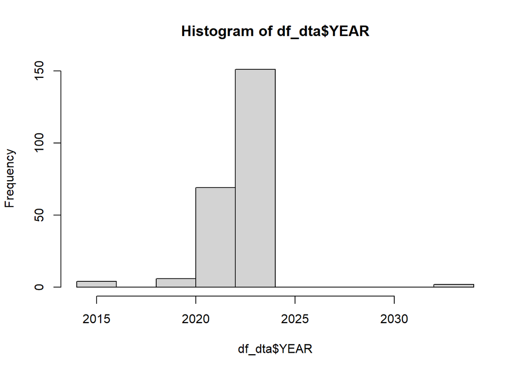

```r
# histogram
hist(df_dta$YEAR)
```

```r
# explain outliers
df_dta[df_dta$YEAR == 2014 & !is.na(df_dta$YEAR), "SOURCE"]
```

```
## # A tibble: 4 × 1
##   SOURCE
##   <chr>
## 1 Pil et al. 2016
## 2 Pil et al. 2016
## 3 Pil et al. 2016
## 4 Pil et al. 2016
```

```r
df_dta[df_dta$SOURCE == "Pil et al. 2016" & !is.na(df_dta$SOURCE), "YEAR"]
```

```
## # A tibble: 6 × 1
##    YEAR
##   <dbl>
## 1  2014
## 2  2014
## 3  2034
## 4  2034
## 5  2014
## 6  2014
```

```r
# correct column
df_dta$YEAR[df_dta$YEAR == 2034] = 2014
table(df_dta$YEAR)
```

```
##
## 2014 2019 2020 2021 2022 2023
##    6    4    2   51   18  151
```

The four datapoints from 2014 are weird, but not impossible, and not improbable enough to remove. Two rows have the year 2034. at first we thought this was a typo for 2024. Upon further analysis we see that all the datapoints with year 2014 are sourced from a study of 2016, this makes sense with the data. However the 2034 columns also come from this study, leading us to the conclusion that they should be from 2014.

### 2.2.15 Indicator proxy

```r
# convert to factor
typeof(df_dta$INDICATOR_PROXY)
```

```
## [1] "character"
```

```r
df_dta$fINDICATOR_PROXY <- as.factor(df_dta$INDICATOR_PROXY)
df_dta <- df_dta %>% relocate(fINDICATOR_PROXY, .after = INDICATOR_PROXY)
df_dta$INDICATOR_PROXY <- NULL

# levels
table(df_dta$fINDICATOR_PROXY)
```

```
##
## Participants who followed treatment and reported side effects
##                                                             1
```

```r
# na values
sum(is.na(df_dta$fINDICATOR_PROXY))
```

```
## [1] 530
```

This does not tell us a lot, the variable will be left in the table, but won’t be used.

### 2.2.16 Measure

```r
# levels
table <- as.data.frame(table(df_dta$MEASURE))
kable(table, format = "markdown")
```

| Var1 | Freq |
| --- | --- |
| Costs for healthcare payer | 1 |
| Participants who received a diagnosis >2 months after 1st consultation | 1 |
| Participants who received diagnosis >1 year after 1st consultation | 1 |
| Participants who reduced their working hours or did not return to work due to their health status | 1 |
| Participants who reported having a very or rather burdensome treatment | 3 |
| Participants who reported having the associated comorbidity | 12 |
| Participants who reported moderate, severe or extreme problems with anxiety/depression | 9 |
| Participants who reported moderate, severe or extreme problems with mobility | 9 |
| Participants who reported moderate, severe or extreme problems with pain/discomfort | 9 |
| Participants who reported moderate, severe or extreme problems with self-care | 9 |
| Participants who reported moderate, severe or extreme problems with usual activities | 9 |
| Participants who reported needing social support in at least one area but did not receive it | 1 |
| Participants who reported needing social support in at least one area but did not receive it, excluding ‘To speak with healthcare professionals (including a psychologist)’ | 1 |
| Participants who reported receiving insufficient or no information | 1 |
| Participants who reported receiving insufficient, no information or too much information | 2 |
| Participants who reported that the information received was not very clear or not clear at all | 3 |
| Participants who reported the physical symptom as very or rather burdensome (>10%) | 36 |
| Participants who reported the psychological symptom as very or rather burdensome (>10%) | 14 |
| Participants who reported the side-effect as very or rather burdensome (>10%) | 14 |
| Participants who reported wanting to have been more involved in treatment choice | 3 |
| Participants who within the last 12 months reported not receiving care when needed | 3 |
| Working individuals before disease who stopped working for at least 1 month and returned to work with reduced schedule or did not return to work | 2 |

```r
# na values
sum(is.na(df_dta$MEASURE))
```

```
## [1] 387
```

These are the measures by which a category is portrayed. A lot of the rows do not have measures, but these may still be useful since it might be deduced from the indicator, comment or meta.

### 2.2.17 Unit

```r
# levels
table <- as.data.frame(table(df_dta$UNIT))
kable(table, format = "markdown")
```

| Var1 | Freq |
| --- | --- |
| % | 131 |
| % of the population | 1 |
| % points | 15 |
| € (billion) | 1 |
| € (million) | 5 |
| € per month | 1 |
| € per patient per month | 3 |
| € per year | 3 |
| Age-standardised incidence per 100 000 | 1 |
| Incidence rate per 100 000 | 1 |
| per 100 000 | 2 |
| Prevalence | 1 |
| Prevalence rate per 100 000 | 1 |
| YLD/case | 3 |
| YLL/death | 1 |

```r
# na values
sum(is.na(df_dta$UNIT))
```

```
## [1] 361
```

These are the units for each measure. There is a lot of missing data, but the measure mostly tells us already what this should be. To normalize the values it will be important to correctly interpret the missing data however.

### 2.2.18 Categories

```r
# levels
table <- as.data.frame(table(df_dta$CATEGORIES))
kable(table, format = "markdown")
```

| Var1 | Freq |
| --- | --- |
| Active CD | 1 |
| Anal pain | 1 |
| Anger or aggressiveness | 1 |
| BEFORE | 18 |
| Blood loss during bowel movements | 1 |
| Breathing difficulties | 1 |
| CD in remission | 1 |
| Change of external characteristics | 1 |
| Chest pain | 1 |
| Chronic fatigue | 1 |
| Concentration problem | 1 |
| Constipation | 1 |
| Constipation and/or diarrhoea | 1 |
| Continuous abdominal pain | 1 |
| Cramps | 1 |
| Diarrhoea | 2 |
| DIFFERENCE | 18 |
| Difficult wound healing | 1 |
| Difficulty in concentrating | 1 |
| Difficulty/loss of memory | 1 |
| Digestive disease | 1 |
| Disease of the locomotor system | 1 |
| Diseases of the liver and/or bile ducts | 1 |
| Dry, painful or itchy skin or rash | 1 |
| Elevated temperature or fever | 1 |
| Eye manifestations | 1 |
| Fatigue | 1 |
| Fatigue or exhaustion | 3 |
| Fatigue or exhaustion | 1 |
| Fear or anxiety | 2 |
| Fear/anxiety | 1 |
| Feeling abandoned | 1 |
| Feeling down, depressed, or sad | 1 |
| Feeling down, depressed, or sadness | 1 |
| Feelings of restlessness, nervousness or irritability | 1 |
| Headache | 2 |
| Heart and blood vessel disease | 1 |
| Heart problems | 1 |
| Infection | 1 |
| Insomnia | 2 |
| Irritability or restlessness | 1 |
| Joint inflammation(s) | 1 |
| Joint pain | 1 |
| Joint pain or arthritis | 1 |
| Joint pain or inflammation | 1 |
| Lack of energy | 1 |
| Libido problems | 1 |
| Liver problems | 1 |
| Loss of appetite | 1 |
| Loss of energy | 1 |
| Lost of smell | 1 |
| Lost of taste | 1 |
| Mood swings | 1 |
| Muscle pain and weakness | 1 |
| Nausea and/or vomiting | 1 |
| Nausea and/vomiting | 1 |
| Nausea or vomiting | 1 |
| None | 1 |
| Osteoporosis | 1 |
| overall WP loss | 1 |
| Pain in the mouth due to, for example, ulcers | 1 |
| Painful wound | 1 |
| Respiratory disease | 1 |
| Skin irritation or eczema | 1 |
| Skin lesions | 1 |
| Skin problems | 1 |
| Stress | 2 |
| Swollen or painful lymph node | 1 |
| TODAY | 18 |
| Urgency or stool urge | 1 |
| Vision problems or eye pain | 1 |
| Weight gain | 2 |
| Weight loss | 1 |

```r
# na values
sum(is.na(df_dta$CATEGORIES))
```

```
## [1] 399
```

For each indicator there are various categories. The value for each category is regulated by a measure and unit for the measure. It seems to differ a lot between categories, which is a problem for clustering. We might need to find another way to classify their importance, perhaps in a more semi-supervised way. For this we would need to gather more data ourselves from experts.

### 2.2.19 Value

```r
# na values
sum(is.na(df_dta$VALUE))
```

```
## [1] 0
```

```r
# value is a character var
typeof(df_dta$VALUE)
```

```
## [1] "character"
```

```r
df_dta$VALUE[!(df_dta$VALUE=="(Missing)") & is.na(suppressWarnings(as.numeric(df_dta$VALUE)))]
```

```
## [1] "Moderately effective"
## [2] "No availability problems"
## [3] "Not applicable"
## [4] "Very effective"
## [5] "Moderately effective"
## [6] "Some availability problems"
## [7] "Moderately effective"
## [8] "Somewhat effective"
## [9] "There exists no treatment for the disease"
```

```r
# transform VALUE
df_dta <- df_dta %>%
  mutate(VALUE = na_if(VALUE, "(Missing)"))

# convert to numeric and add extra column for non numeric to not lose data
df_dta$VALUE_num <- suppressWarnings(as.numeric(df_dta$VALUE))
df_dta$VALUE_char <- ifelse(is.na(df_dta$VALUE_num), df_dta$VALUE, NA)
df_dta <- df_dta %>% relocate(VALUE_num, .after = VALUE)
df_dta <- df_dta %>% relocate(VALUE_char, .after = VALUE_num)



df_dta[, c("VALUE_num", "VALUE_char")]
```

```
## # A tibble: 531 × 2
##    VALUE_num VALUE_char
##        <dbl> <chr>
##  1      0.14 <NA>
##  2      0.85 <NA>
##  3      0.7  <NA>
##  4     -0.15 <NA>
##  5     49    <NA>
##  6     46.7  <NA>
##  7     13.3  <NA>
##  8     12.7  <NA>
##  9      7.3  <NA>
## 10      7.3  <NA>
## # ℹ 521 more rows
```

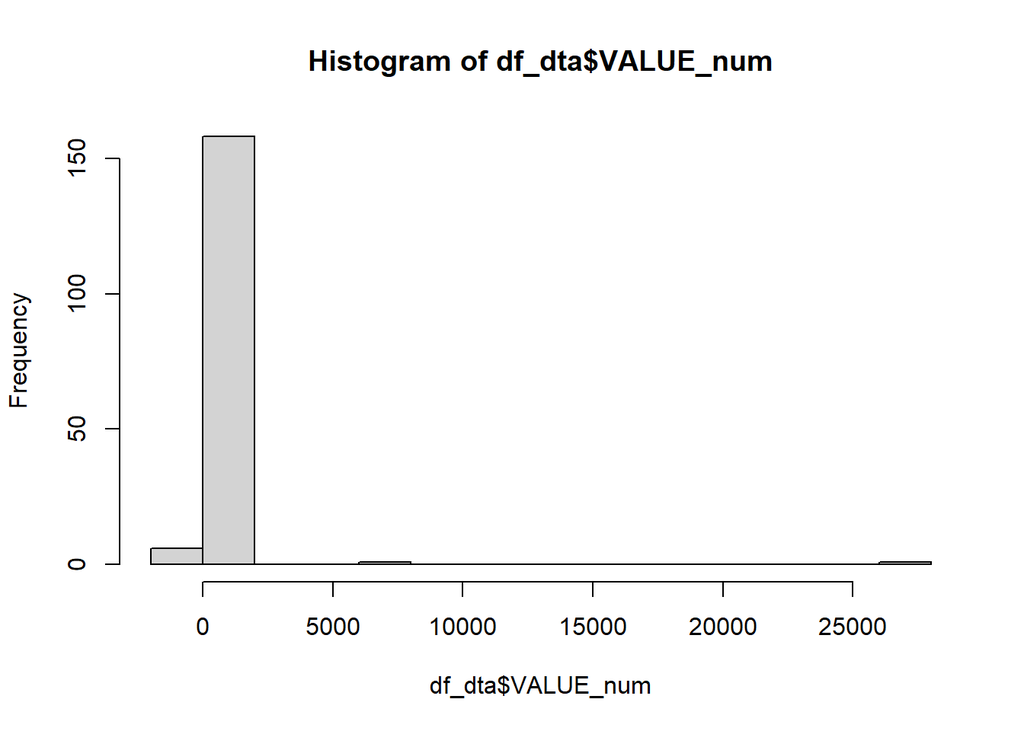

```r
# analysis
hist(df_dta$VALUE_num, breaks = 10)
```

There are both numerical and plain text values, we separate them so we can work with both. In the histogram it is apparent that these values are not on the same scale, they should be scaled so different values can be compared.

### 2.2.20 SD

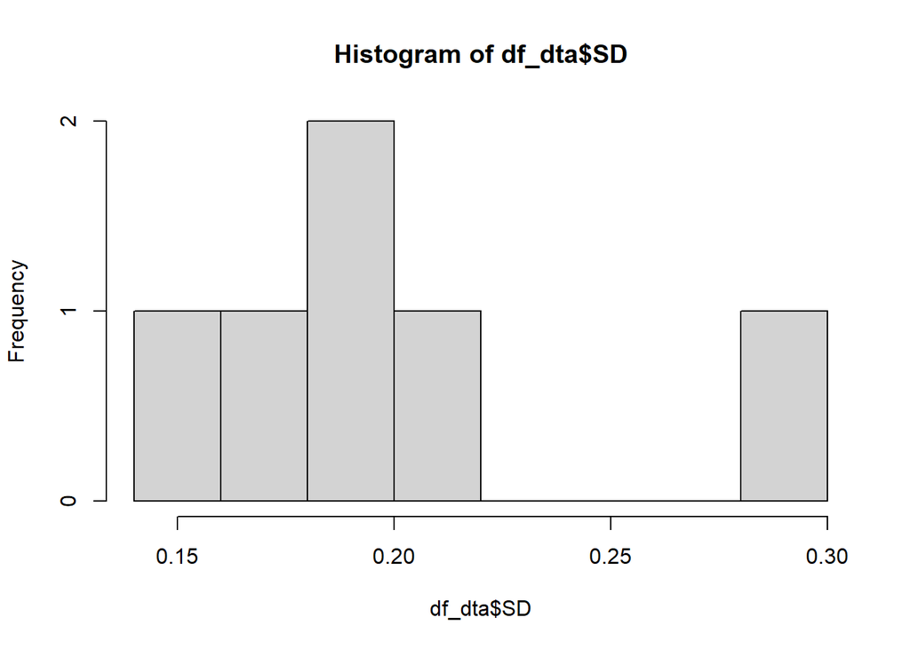

```r
hist(df_dta$SD, breaks = 10)
```

```r
# na values
sum(is.na(df_dta$SD))
```

```
## [1] 525
```

This variable is not often reported upon and can probably not be used for our purposes either.

### 2.2.21 Lower CI

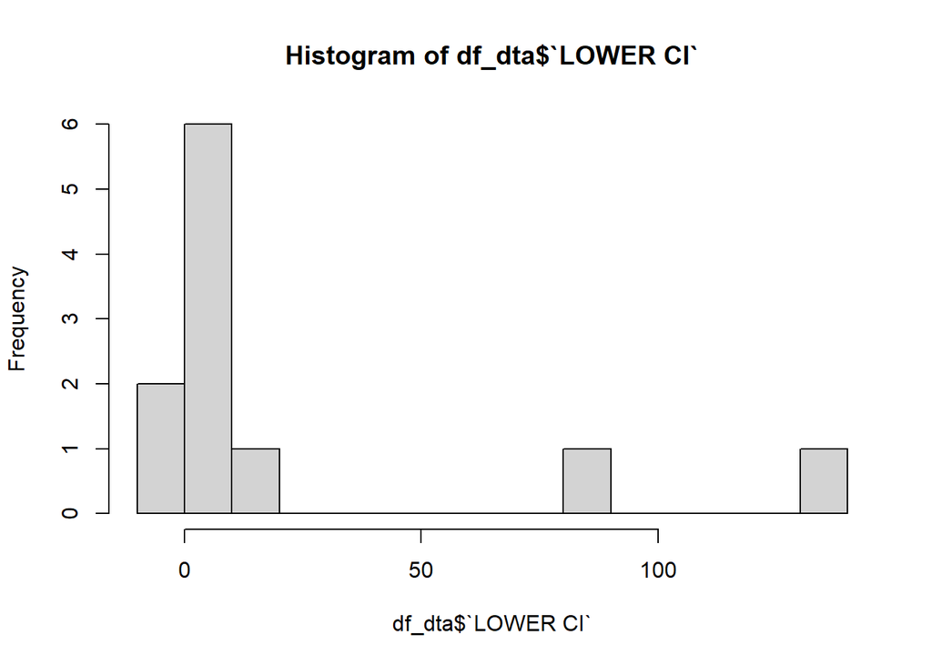

```r
hist(df_dta$`LOWER CI`, breaks = 10)
```

```r
# na values
sum(is.na(df_dta$`LOWER CI`))
```

```
## [1] 520
```

### 2.2.22 Upper CI

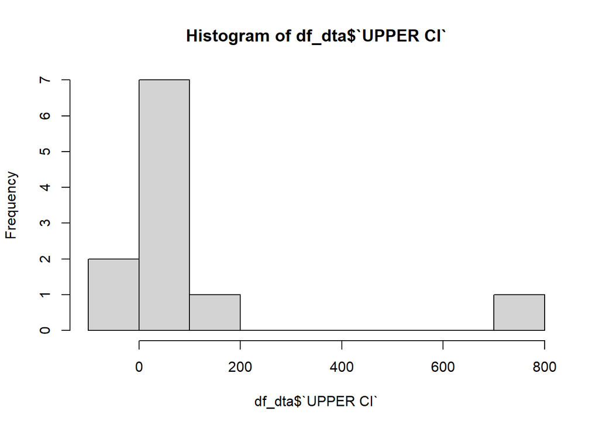

```r
hist(df_dta$`UPPER CI`, breaks = 10)
```

```r
# na values
sum(is.na(df_dta$`UPPER CI`))
```

```
## [1] 520
```

These two variables follow the same analysis as **SD**.

### 2.2.23 Source

```r
table(df_dta$SOURCE)
```

```
##
##                                                                                                                                                                                                           BeBoD
##                                                                                                                                                                                                               4
##                                                                                                                                                                                                           BeBOD
##                                                                                                                                                                                                               1
##                                                                                                   Del Marmol et al. 2022; Forsea et al. 2013; Fondation Contre Le Cancer 2021; Fondation Contre Le Cancer 2024.
##                                                                                                                                                                                                               1
## Devleesschauwer, B., Willem, L., Jurčević, J., Smith, P., Scohy, A., Wyper, G. M., ... & De Pauw, R. (2023). The direct disease burden of COVID-19 in Belgium in 2020 and 2021. BMC public health, 23(1), 1707.
##                                                                                                                                                                                                               1
##                                                                                                                                                                                                  Expert opinion
##                                                                                                                                                                                                               2
##                                                                                                                                                                                                         Experts
##                                                                                                                                                                                                               1
##                                                                                                                                                                                            Forum KCE report 344
##                                                                                                                                                                                                               1
##                                                                                                                                                                                                             GBD
##                                                                                                                                                                                                               3
##                     Hastie, C.E., Lowe, D.J., McAuley, A. et al. True prevalence of long-COVID in a nationwide, population cohort study. Nat Commun 14, 7892 (2023). https://doi.org/10.1038/s41467-023-43661-w
##                                                                                                                                                                                                               1
##                                                                                                                                                                                                     Holko et al
##                                                                                                                                                                                                               2
##                                                                                                                                                                Misík et al 2019; Castellano-Hinojosa et al 2023
##                                                                                                                                                                                                               1
##                                                                                                                                                                                                  NEED interview
```

[output cut: 13 more lines]

```r
# na values
sum(is.na(df_dta$SOURCE))
```

```
## [1] 353
```

This contains the source for the datapoints. It is not useful for building the priority model, but it is useful to see where the data came from.

### 2.2.24 Rating

```r
# non na values
sum(!is.na(df_dta$RATING))
```

```
## [1] 0
```

```r
# na values
sum(is.na(df_dta$RATING))
```

```
## [1] 531
```

```r
# no values so column can be removed
df_dta$RATING <- NULL
```

This variable contains no data, so it can be safely removed.

### 2.2.25 Key points

```r
head(df_dta[!is.na(df_dta$KEY_POINT), "KEY_POINT"])
```

```
## # A tibble: 6 × 1
##   KEY_POINT
##   <chr>
## 1 "\"Patients reported uncertainty about whether symptoms were directly caused …
## 2 "\"Intense fatigue and a permanent state of weakness  impacted their daily ac…
## 3 "\"Need to spend long hours in the restroom.\""
## 4 "\"Need to spend long hours in the restroom.\""
## 5 "\"Need to spend long hours in the restroom.\""
## 6 "\"Stress stemmed from the fear of disease progression or worsening over time…
```

```r
# na values
sum(is.na(df_dta$KEY_POINT))
```

```
## [1] 475
```

A lot of missing values so we need to have a system where rows without keypoints do not necessarily get a lower score. This variable needs to stay in plain text for classifying it with NLP. There are sometimes multiple quotes separated by a ‘;’, we will leave it like this for now.

### 2.2.26 Quotes

```r
head(df_dta[!is.na(df_dta$QUOTES), "QUOTES"])
```

```
## # A tibble: 6 × 1
##   QUOTES
##   <chr>
## 1 "\"I used to take long naps, spend a lot of time on the couch, and I kept tel…
## 2 "\"It was big, big cramps in my abdomen. Vomiting all day long.”; \"So I had …
## 3 "\"Been home for a week, and I found the fatigue very heavy, I would always s…
## 4 "\"Of course, you can't do much during a crisis. Standing up for ten minutes …
## 5 "\"I don't just say because I also have a lot of rheumatological problems. An…
## 6 "\"It was big, big cramps in my abdomen. Vomiting all day long.” ; \"So I had…
```

```r
# na values
sum(is.na(df_dta$QUOTES))
```

```
## [1] 470
```

The same applies to the quotes as for the keypoints.

### 2.2.27 Meta 1

```r
head(df_dta[!is.na(df_dta$META_1), "META_1"])
```

```
## # A tibble: 6 × 1
##   META_1
##   <chr>
## 1 Range: − 0.532; 1
## 2 Range: − 0.532; 1
## 3 Average before minus the average today
## 4 Included categories - consultations, medications, suppelements and other expe…
## 5 Included categories - consultations, medications, suppelements and other expe…
## 6 Included categories - consultations, medications, suppelements and other expe…
```

```r
# na values
sum(is.na(df_dta$META_1))
```

```
## [1] 499
```

This is extra information about datapoints that needs to be taken into account if we want to remove or alter them.

### 2.2.28 Meta 2

```r
head(df_dta[!is.na(df_dta$META_2), "META_2"])
```

```
## # A tibble: 3 × 1
##   META_2
##   <chr>
## 1 P-HBI (patient Harvey Bradshaw index) score > 4 denoting active disease
## 2 P-HBI (patient Harvey Bradshaw index) score < or = 4 denoting disease in remi…
## 3 P-HBI (patient Harvey Bradshaw index) score > 4 denoting active disease
```

```r
# na values
sum(is.na(df_dta$META_2))
```

```
## [1] 528
```

The same as metadata 1.

### 2.2.29 Meta 3

```r
head(df_dta[!is.na(df_dta$META_3), "META_3"])
```

```
## # A tibble: 0 × 1
## # ℹ 1 variable: META_3 <lgl>
```

```r
# na values
sum(is.na(df_dta$META_3))
```

```
## [1] 531
```

```r
# remove column
df_dta$META_3 <- NULL
```

This column contains no data so it can be removed.

### 2.2.30 Criterion 2

```r
head(df_dta[!is.na(df_dta$CRITERION2), "CRITERION2"])
```

```
## # A tibble: 6 × 1
##   CRITERION2
##   <chr>
## 1 Impact on general health-related quality of life
## 2 Impact on general health-related quality of life
## 3 Impact on physical health
## 4 Impact on physical health
## 5 Impact on physical health
## 6 Impact on physical health
```

```r
# na values
sum(is.na(df_dta$CRITERION2))
```

```
## [1] 463
```

```r
# check similarity to criterion 1
df_dta[!is.na(df_dta$CRITERION2) &
       as.character(df_dta$fCRITERION) != as.character(df_dta$CRITERION2),
       c("fCRITERION", "CRITERION2")]
```

```
## # A tibble: 4 × 2
##   fCRITERION                   CRITERION2
##   <fct>                        <chr>
## 1 Forecasted burden of disease Burden of disease
## 2 Forecasted burden of disease Burden of disease
## 3 Forecasted healthcare costs  Economic burden
## 4 Impact on life expectancy    Impact on mortality
```

```r
# remove column
df_dta$CRITERION2 <- NULL
```

This column seems to contain the exact same data as **CRITERION** except less rows are filled in and it is formulated differently. This variable can thus be removed.

### 2.2.31 Comments

```r
head(df_dta[!is.na(df_dta$COMMENTS), "COMMENTS"])
```

```
## # A tibble: 6 × 1
##   COMMENTS
##   <chr>
## 1 "Mainly cutaneous melanoma. C69.3 malignant neoplasm of choroid not included?…
## 2 "Not Known"
## 3 "Not a reliable estimate given that only 50% of respondents reported having r…
## 4 "NB. Reported by >10% of those who received treatment ==> but not accurate es…
## 5 "N.B. This mainly highlights the problems and doesn't provide info on positiv…
## 6 "Also include those who said \"too much information\" in inadequate amount?"
```

```r
# na values
sum(is.na(df_dta$COMMENTS))
```

```
## [1] 516
```

Like metadata, some extra information that might be useful.

### 2.2.32 Qualy

```r
head(df_dta[!is.na(df_dta$QUALY), "QUALY"])
```

```
## # A tibble: 0 × 1
## # ℹ 1 variable: QUALY <lgl>
```

```r
# na values
sum(is.na(df_dta$QUALY))
```

```
## [1] 531
```

```r
# no data so remove column
df_dta$QUALY <- NULL
```

This column contains no data, so can be removed.

### 2.2.33 Value_Viz

```r
print(typeof(df_dta$VALUE_VIZ))
```

```
## [1] "double"
```

```r
# check difference with VALUE
identical(df_dta$VALUE_num, df_dta$VALUE_VIZ)
```

```
## [1] TRUE
```

```r
# remove column
df_dta$VALUE_VIZ <- NULL
```

This variable is the exact same as the numerical part of **VALUE**. It can therefore be deleted.

## 2.3 Univariate conclusion

After the univariate analysis the data looks as follows:

```r
head(df_dta)
```

```
## # A tibble: 6 × 26
##   fDISEASE       fSEX  fDIMENSION fDOMAIN fCRITERION fINDICATOR fDISEASE_SUBTYPE
##   <fct>          <fct> <fct>      <fct>   <fct>      <fct>      <fct>
## 1 Crohns Disease Both… Patients   Health  Impact on… Years of … <NA>
## 2 Crohns Disease Both… Patients   Health  Impact on… EQ-5D-5L … <NA>
## 3 Crohns Disease Both… Patients   Health  Impact on… EQ-5D-5L … <NA>
## 4 Crohns Disease Both… Patients   Health  Impact on… EQ-5D-5L … <NA>
## 5 Crohns Disease Both… Patients   Health  Impact on… Associate… <NA>
## 6 Crohns Disease Both… Patients   Health  Impact on… Associate… <NA>
## # ℹ 19 more variables: fDISEASE_PROXY <fct>, fCOUNTRY_PROXY <fct>, YEAR <dbl>,
## #   fINDICATOR_PROXY <fct>, MEASURE <chr>, UNIT <chr>, CATEGORIES <chr>,
## #   VALUE <chr>, VALUE_num <dbl>, VALUE_char <chr>, SD <dbl>, `LOWER CI` <dbl>,
## #   `UPPER CI` <dbl>, SOURCE <chr>, KEY_POINT <chr>, QUOTES <chr>,
## #   META_1 <chr>, META_2 <chr>, COMMENTS <chr>
```

```r
dim(df_dta)
```

```
## [1] 531  26
```

The useful variables for further analysis are:

- fDISEASE
- fDIMENSION
- fDOMAIN
- fCRITERION
- fINDICATOR
- YEAR
- MEASURE
- UNIT
- CATEGORIES
- VALUE_num
- VALUE_char
- KEY_POINT
- QUOTES
- META/COMMENTS

Either because they were duplicates of other columns or if they contained no values, or all the same ones.

The remaining columns with (substantial) missing data are: * (fDISEASE_SUBTYPE) * (fDISEASE_PROXY) * (fCOUNTRY_PROXY) * YEAR * (fINDICATOR_PROXY) * MEASURE * UNIT * CATEGORIES * VALUE * SOURCE * KEY_POINT * QUOTES * META/COMMENTS

The variables in brackets are not important for further analysis, since they are too sparse and/or don’t tell anything about the diseases or criteria. They will be left in the dataset to see if we can get any conclusions on these with our model. For creating the model, they are not useful.

The most important findings are that many of the variables are only sparsely filled in, and we identified the important variables for further analysis.

## 2.4 Multivariate

A lot of analysis between certain variables is not useful, or at least not to great extend, so they are not done here. **SEX** will be analysed first, because there is something going on with it that will give a skewed view of the other variables.

### 2.4.1 Sex

#### 2.4.1.1 Disease x Sex

```r
crossTable <- table(df_dta$fDISEASE, df_dta$fSEX)
crossTable_df <- as.data.frame.matrix(crossTable)
kable(crossTable_df, caption = "Cross Table of fDISEASE and fDISEASE_SUBTYPE")
```

|  | Both sexes | Men | Women |
| --- | --- | --- | --- |
| Crohns Disease | 101 | 47 | 47 |
| Long COVID | 74 | 47 | 47 |
| Malignant melanoma | 74 | 47 | 47 |

The data shows for every disease the data for both sexes, and than for each sex separately. These numbers do not add up under this assumption, however. This will be explored under the **SEX**-subsection.

#### 2.4.1.2 Disease x Sex x Criterion

```r
df_dta_temp <- df_dta[df_dta$fDISEASE == "Crohns Disease", ]
crossTable <- table(df_dta_temp$fCRITERION, df_dta_temp$fSEX)
crossTable_df <- as.data.frame.matrix(crossTable)
kable(crossTable_df, caption = "Crohns Disease: Cross Table of fCRITERION and fSEX")
```

Crohns Disease: Cross Table of fCRITERION and fSEX

|  | Both sexes | Men | Women |
| --- | --- | --- | --- |
| Accessibility | 2 | 2 | 2 |
| Burden of treatment | 8 | 2 | 2 |
| Burden on informal caregivers | 1 | 1 | 1 |
| Effectiveness of treatment | 1 | 1 | 1 |
| Environmental impact of standard of care | 3 | 3 | 3 |
| Financial consequences | 3 | 2 | 2 |
| Forecasted burden of disease | 3 | 3 | 3 |
| Forecasted healthcare costs | 1 | 1 | 1 |
| Forecasted productivity losses | 1 | 1 | 1 |
| Frequency | 4 | 2 | 2 |
| Impact of social life | 1 | 1 | 1 |
| Impact on autonomy | 9 | 3 | 3 |
| Impact on education | 1 | 1 | 1 |
| Impact on general health-related quality of life | 12 | 4 | 4 |
| Impact on life expectancy | 2 | 2 | 2 |
| Impact on mortality | 1 | 1 | 1 |
| Impact on physical health | 23 | 2 | 2 |
| Impact on psychological health | 12 | 3 | 3 |
| Impact on social life | 1 | 1 | 1 |
| Impact on work | 1 | 1 | 1 |
| Preventability | 1 | 1 | 1 |
| Productivity losses | 3 | 2 | 2 |
| Quality of care | 5 | 5 | 5 |
| Transmissibility | 1 | 1 | 1 |
| Value for money of standard of care | 1 | 1 | 1 |

```r
df_dta_temp <- df_dta[df_dta$fDISEASE == "Long COVID", ]
crossTable <- table(df_dta_temp$fCRITERION, df_dta_temp$fSEX)
crossTable_df <- as.data.frame.matrix(crossTable)
kable(crossTable_df, caption = "Long COVID: Cross Table of fCRITERION and fSEX")
```

Long COVID: Cross Table of fCRITERION and fSEX

|  | Both sexes | Men | Women |
| --- | --- | --- | --- |
| Accessibility | 2 | 2 | 2 |
| Burden of treatment | 2 | 2 | 2 |
| Burden on informal caregivers | 1 | 1 | 1 |
| Effectiveness of treatment | 1 | 1 | 1 |
| Environmental impact of standard of care | 3 | 3 | 3 |
| Financial consequences | 2 | 2 | 2 |
| Forecasted burden of disease | 3 | 3 | 3 |
| Forecasted healthcare costs | 1 | 1 | 1 |
| Forecasted productivity losses | 1 | 1 | 1 |
| Frequency | 2 | 2 | 2 |
| Impact of social life | 1 | 1 | 1 |
| Impact on autonomy | 9 | 3 | 3 |
| Impact on education | 1 | 1 | 1 |
| Impact on general health-related quality of life | 9 | 4 | 4 |
| Impact on life expectancy | 2 | 2 | 2 |
| Impact on mortality | 1 | 1 | 1 |
| Impact on physical health | 14 | 2 | 2 |
| Impact on psychological health | 6 | 3 | 3 |
| Impact on social life | 1 | 1 | 1 |
| Impact on work | 1 | 1 | 1 |
| Preventability | 1 | 1 | 1 |
| Productivity losses | 3 | 2 | 2 |
| Quality of care | 5 | 5 | 5 |
| Transmissibility | 1 | 1 | 1 |
| Value for money of standard of care | 1 | 1 | 1 |

```r
df_dta_temp <- df_dta[df_dta$fDISEASE == "Malignant melanoma", ]
crossTable <- table(df_dta_temp$fCRITERION, df_dta_temp$fSEX)
crossTable_df <- as.data.frame.matrix(crossTable)
kable(crossTable_df, caption = "Malignant melanoma: Cross Table of fCRITERION and fSEX")
```

Malignant melanoma: Cross Table of fCRITERION and fSEX

|  | Both sexes | Men | Women |
| --- | --- | --- | --- |
| Accessibility | 2 | 2 | 2 |
| Burden of treatment | 8 | 2 | 2 |
| Burden on informal caregivers | 1 | 1 | 1 |
| Effectiveness of treatment | 2 | 1 | 1 |
| Environmental impact of standard of care | 3 | 3 | 3 |
| Financial consequences | 2 | 2 | 2 |
| Forecasted burden of disease | 3 | 3 | 3 |
| Forecasted healthcare costs | 1 | 1 | 1 |
| Forecasted productivity losses | 1 | 1 | 1 |
| Frequency | 3 | 2 | 2 |
| Impact of social life | 1 | 1 | 1 |
| Impact on autonomy | 9 | 3 | 3 |
| Impact on education | 1 | 1 | 1 |
| Impact on general health-related quality of life | 6 | 4 | 4 |
| Impact on life expectancy | 2 | 2 | 2 |
| Impact on mortality | 1 | 1 | 1 |
| Impact on physical health | 6 | 2 | 2 |
| Impact on psychological health | 10 | 3 | 3 |
| Impact on social life | 1 | 1 | 1 |
| Impact on work | 1 | 1 | 1 |
| Preventability | 1 | 1 | 1 |
| Productivity losses | 2 | 2 | 2 |
| Quality of care | 5 | 5 | 5 |
| Transmissibility | 1 | 1 | 1 |
| Value for money of standard of care | 1 | 1 | 1 |

One example is printed out to see the problem with the missing criteria.

```r
df_dta[df_dta$fDISEASE == "Crohns Disease" & df_dta$fCRITERION == "Burden of treatment", ]
```

```
## # A tibble: 12 × 26
##    fDISEASE      fSEX  fDIMENSION fDOMAIN fCRITERION fINDICATOR fDISEASE_SUBTYPE
##    <fct>         <fct> <fct>      <fct>   <fct>      <fct>      <fct>
##  1 Crohns Disea… Both… Patients   Health… Burden of… Experienc… <NA>
##  2 Crohns Disea… Both… Patients   Health… Burden of… Experienc… <NA>
##  3 Crohns Disea… Both… Patients   Health… Burden of… Experienc… <NA>
##  4 Crohns Disea… Both… Patients   Health… Burden of… Experienc… <NA>
##  5 Crohns Disea… Both… Patients   Health… Burden of… Experienc… <NA>
##  6 Crohns Disea… Both… Patients   Health… Burden of… Experienc… <NA>
##  7 Crohns Disea… Both… Patients   Health… Burden of… Experienc… <NA>
##  8 Crohns Disea… Both… Patients   Health… Burden of… Experienc… <NA>
##  9 Crohns Disea… Men   Patients   Health… Burden of… Experienc… <NA>
## 10 Crohns Disea… Men   Patients   Health… Burden of… Experienc… <NA>
## 11 Crohns Disea… Women Patients   Health… Burden of… Experienc… <NA>
## 12 Crohns Disea… Women Patients   Health… Burden of… Experienc… <NA>
## # ℹ 19 more variables: fDISEASE_PROXY <fct>, fCOUNTRY_PROXY <fct>, YEAR <dbl>,
## #   fINDICATOR_PROXY <fct>, MEASURE <chr>, UNIT <chr>, CATEGORIES <chr>,
## #   VALUE <chr>, VALUE_num <dbl>, VALUE_char <chr>, SD <dbl>, `LOWER CI` <dbl>,
## #   `UPPER CI` <dbl>, SOURCE <chr>, KEY_POINT <chr>, QUOTES <chr>,
## #   META_1 <chr>, META_2 <chr>, COMMENTS <chr>
```

The missing data with the specific sexes seems to just be that the categories are not filled in. Therefore, there is no reason to show an indicator multiple times.

#### 2.4.1.3 Disease x Sex x (Value, Keypoint, Quote)

```r
df_dta %>%
  filter(fDISEASE == "Crohns Disease") %>%
  group_by(fSEX) %>%  # Group by sex
  summarise(
    proportion_non_missing = mean(!is.na(VALUE) | !is.na(KEY_POINT) | !is.na(QUOTES))  # Check if any column is non-missing
  ) %>%
  kable(digits = 3, col.names = c("Sex", "Chrohns Disease: Proportion (Value or Keypoint or Quote not missing)"))
```

| Sex | Chrohns Disease: Proportion (Value or Keypoint or Quote not missing) |
| --- | --- |
| Both sexes | 0.802 |
| Men | 0.000 |
| Women | 0.000 |

```r
df_dta %>%
  filter(fDISEASE == "Long COVID") %>%
  group_by(fSEX) %>%  # Group by sex
  summarise(
    proportion_non_missing = mean(!is.na(VALUE) | !is.na(KEY_POINT) | !is.na(QUOTES))  # Check if any column is non-missing
  ) %>%
  kable(digits = 3, col.names = c("Sex", "Long COVID: Proportion (Value or Keypoint or Quote not missing)"))
```

| Sex | Long COVID: Proportion (Value or Keypoint or Quote not missing) |
| --- | --- |
| Both sexes | 0.568 |
| Men | 0.000 |
| Women | 0.000 |

```r
df_dta %>%
  filter(fDISEASE == "Malignant melanoma") %>%
  group_by(fSEX) %>%  # Group by sex
  summarise(
    proportion_non_missing = mean(!is.na(VALUE) | !is.na(KEY_POINT) | !is.na(QUOTES))  # Check if any column is non-missing
  ) %>%
  kable(digits = 3, col.names = c("Sex", "Malignant melanoma: Proportion (Value or Keypoint or Quote not missing)"))
```

| Sex | Malignant melanoma: Proportion (Value or Keypoint or Quote not missing) |
| --- | --- |
| Both sexes | 0.797 |
| Men | 0.021 |
| Women | 0.021 |

Most of the data under the specific sexes are missing. Seeing as this data is a subdivision of the ‘both sexes’-category we can just use this one category. We just will not be able to make predictions or decisions based on the specific sex.

Just to be sure the non-missing data is prined out.

```r
df_dta[(!is.na(df_dta$VALUE) | !is.na(df_dta$KEY_POINT) | !is.na(df_dta$QUOTES)) & (df_dta$fSEX == "Men" | df_dta$fSEX == "Women"), ]
```

```
## # A tibble: 2 × 26
##   fDISEASE       fSEX  fDIMENSION fDOMAIN fCRITERION fINDICATOR fDISEASE_SUBTYPE
##   <fct>          <fct> <fct>      <fct>   <fct>      <fct>      <fct>
## 1 Malignant mel… Men   Society    Social  Productiv… Costs rel… <NA>
## 2 Malignant mel… Women Society    Social  Productiv… Costs rel… <NA>
## # ℹ 19 more variables: fDISEASE_PROXY <fct>, fCOUNTRY_PROXY <fct>, YEAR <dbl>,
## #   fINDICATOR_PROXY <fct>, MEASURE <chr>, UNIT <chr>, CATEGORIES <chr>,
## #   VALUE <chr>, VALUE_num <dbl>, VALUE_char <chr>, SD <dbl>, `LOWER CI` <dbl>,
## #   `UPPER CI` <dbl>, SOURCE <chr>, KEY_POINT <chr>, QUOTES <chr>,
## #   META_1 <chr>, META_2 <chr>, COMMENTS <chr>
```

This is not enough data to work with, the specific sexes rows will be removed.

```r
df_dta <- df_dta[df_dta$fSEX == "Both sexes", ]
df_dta$fSEX <- NULL
dim(df_dta)
```

```
## [1] 249  25
```

### 2.4.2 Disease

#### 2.4.2.1 Disease x Dimension

```r
crossTable <- table(df_dta$fDISEASE, df_dta$fDIMENSION)
crossTable_df <- as.data.frame.matrix(crossTable)
kable(crossTable_df, caption = "Cross Table of fDISEASE and fDIMENSION")
```

Cross Table of fDISEASE and fDIMENSION

|  | Future | Patients | Society |
| --- | --- | --- | --- |
| Crohns Disease | 5 | 82 | 14 |
| Long COVID | 5 | 57 | 12 |
| Malignant melanoma | 5 | 57 | 12 |

All dimensions are accounted for, for all diseases, and can be used to differentiate between different dimensions of the indicators.

#### 2.4.2.2 Disease x Domain

```r
crossTable <- table(df_dta$fDISEASE, df_dta$fDOMAIN)
crossTable_df <- as.data.frame.matrix(crossTable)
kable(crossTable_df, caption = "Cross Table of fDISEASE and fDOMAIN")
```

Cross Table of fDISEASE and fDOMAIN

|  | Health | Healthcare | Social |
| --- | --- | --- | --- |
| Crohns Disease | 68 | 19 | 14 |
| Long COVID | 48 | 13 | 13 |
| Malignant melanoma | 42 | 20 | 12 |

The same comments apply to domain as to dimension.

#### 2.4.2.3 Disease x Criterion

```r
crossTable <- table(df_dta$fCRITERION, df_dta$fDISEASE)
crossTable_df <- as.data.frame.matrix(crossTable)
kable(crossTable_df, caption = "Cross Table of fCRITERION and fID")
```

Cross Table of fCRITERION and fID

|  | Crohns Disease | Long COVID | Malignant melanoma |
| --- | --- | --- | --- |
| Accessibility | 2 | 2 | 2 |
| Burden of treatment | 8 | 2 | 8 |
| Burden on informal caregivers | 1 | 1 | 1 |
| Effectiveness of treatment | 1 | 1 | 2 |
| Environmental impact of standard of care | 3 | 3 | 3 |
| Financial consequences | 3 | 2 | 2 |
| Forecasted burden of disease | 3 | 3 | 3 |
| Forecasted healthcare costs | 1 | 1 | 1 |
| Forecasted productivity losses | 1 | 1 | 1 |
| Frequency | 4 | 2 | 3 |
| Impact of social life | 1 | 1 | 1 |
| Impact on autonomy | 9 | 9 | 9 |
| Impact on education | 1 | 1 | 1 |
| Impact on general health-related quality of life | 12 | 9 | 6 |
| Impact on life expectancy | 2 | 2 | 2 |
| Impact on mortality | 1 | 1 | 1 |
| Impact on physical health | 23 | 14 | 6 |
| Impact on psychological health | 12 | 6 | 10 |
| Impact on social life | 1 | 1 | 1 |
| Impact on work | 1 | 1 | 1 |
| Preventability | 1 | 1 | 1 |
| Productivity losses | 3 | 3 | 2 |
| Quality of care | 5 | 5 | 5 |
| Transmissibility | 1 | 1 | 1 |
| Value for money of standard of care | 1 | 1 | 1 |

#### 2.4.2.4 Missing values per disease

```r
# Define variables of interest
vars <- c("MEASURE", "UNIT", "CATEGORIES", "VALUE_num", "VALUE_char", "KEY_POINT", "QUOTES", "META_1", "META_2", "COMMENTS")

# Calculate proportion of missing values per disease
missing_table <- sapply(vars, function(var) {
  tapply(is.na(df_dta[[var]]), df_dta$fDISEASE, mean, na.rm = TRUE)
})

# Convert to a data frame
missing_table_df <- as.data.frame(t(missing_table))

# Print as a formatted table
kable(digits=2, missing_table_df, caption = "Proportion of Missing Values per Disease")
```

Proportion of Missing Values per Disease

|  | Crohns Disease | Long COVID | Malignant melanoma |
| --- | --- | --- | --- |
| MEASURE | 0.36 | 0.49 | 0.45 |
| UNIT | 0.27 | 0.39 | 0.34 |
| CATEGORIES | 0.39 | 0.51 | 0.54 |
| VALUE_num | 0.25 | 0.49 | 0.32 |
| VALUE_char | 0.97 | 0.97 | 0.95 |
| KEY_POINT | 0.78 | 0.93 | 0.61 |
| QUOTES | 0.71 | 0.88 | 0.69 |
| META_1 | 0.93 | 0.73 | 0.93 |
| META_2 | 0.97 | 1.00 | 1.00 |
| COMMENTS | 1.00 | 1.00 | 0.80 |

There are a big amount of missing rows for these variables. The meta and comments-data even has barely any filled-in columns. In the data cleaning we will have to carefully traverse these rows to see which ones are usable.

#### 2.4.2.5 Comments

It is not useful to analyse any of the other variables together (bivariatly) with **fDISEASE**, because the other variables are all in function of the indicators. Indicators x Disease is only relevant itself in reference to the criteria. Columns like: **MEASURE**, **UNIT**, **CATEGORIES** are here analyzed together with the diseases, but only to see the distribution of missing values. Comparing all their actual values to **fDISEASE** does not make sense bivariatly.

### 2.4.3 Criterion & indicator

#### 2.4.3.1 Disease x Criterion x Indicator

```r
# Crohns disease
grouped_df <- df_dta[df_dta$fDISEASE == "Crohns Disease", ] %>%
  filter(!is.na(fCRITERION), !is.na(fINDICATOR)) %>%
  group_by(fCRITERION) %>%
  summarise(Indicators = paste(unique(fINDICATOR), collapse = " | ")) %>%
  ungroup()

kable(grouped_df, caption = "Crohns Disease: fCRITERION and Associated fINDICATORs")
```

Crohns Disease: fCRITERION and Associated fINDICATORs

| fCRITERION | Indicators |
| --- | --- |
| Accessibility | Treatment availability \| Foregone care |
| Burden of treatment | Experienced burden of treatment \| Experienced burden of side-effects of treatment |
| Burden on informal caregivers | Loss in informal caregiver’s quality of life |
| Effectiveness of treatment | Effectiveness of treatment |
| Environmental impact of standard of care | Greenhouse gas emissions related to the standard of care \| Hazardous waste related to standard of care \| Use of natural resources and raw materials related to standard of care |
| Financial consequences | Out-of-pocket healthcare costs \| Non-healthcare costs |
| Forecasted burden of disease | Forecasted incidence or prevalence \| Forecasted years of life lost \| Forecasted years lived with disability |
| Forecasted healthcare costs | Forecasted healthcare costs attributable to the health condition |
| Forecasted productivity losses | Forecasted productivity losses attributable to the health condition |
| Frequency | Incidence or prevalence \| Prevalence |
| Impact of social life | Social support needs |
| Impact on autonomy | Mobility \| Self-care \| Usual activities |
| Impact on education | Years of education lost |
| Impact on general health-related quality of life | Years of life lived with disability (per case) \| EQ-5D-5L average score \| Associated comorbidities \| EQ-5D average score |
| Impact on life expectancy | Years of Life Lost \| Years of Life Lost (per death) |
| Impact on mortality | Years of Life Lost |
| Impact on physical health | Experienced burden of physical symptoms \| Pain/discomfort |
| Impact on psychological health | Experienced burden of psychological symptoms related to the health issue \| Anxiety/depression \| Experienced burden of psychological symptoms |
| Impact on social life | Social support needs |
| Impact on work | Changes in working time |
| Preventability | Implementation of effective primary prevention strategies |
| Productivity losses | Costs related to work absenteeism, presenteeism, early labor force exits of patients \| Costs related to work absenteeism, presenteeism or/and early labor force exits of caregivers |
| Quality of care | Experience with the organisation of care \| Quantity of information received \| Clarity of information received \| Involvement in treatment choice \| Diagnostic timing |
| Transmissibility | Basic reproduction number |
| Value for money of standard of care | Healthcare costs per unit of health gain |

```r
# long covid
grouped_df <- df_dta[df_dta$fDISEASE == "Long COVID", ] %>%
  filter(!is.na(fCRITERION), !is.na(fINDICATOR)) %>%
  group_by(fCRITERION) %>%
  summarise(Indicators = paste(unique(fINDICATOR), collapse = " | ")) %>%
  ungroup()

kable(grouped_df, caption = "Long COVID: fCRITERION and Associated fINDICATORs")
```

Long COVID: fCRITERION and Associated fINDICATORs

| fCRITERION | Indicators |
| --- | --- |
| Accessibility | Treatment availability \| Foregone care |
| Burden of treatment | Experienced burden of treatment \| Experienced burden of side-effects of treatment |
| Burden on informal caregivers | Loss in informal caregiver’s quality of life |
| Effectiveness of treatment | Effectiveness of treatment |
| Environmental impact of standard of care | Greenhouse gas emissions related to the standard of care \| Hazardous waste related to standard of care \| Use of natural resources and raw materials related to standard of care |
| Financial consequences | Out-of-pocket healthcare costs \| Non-healthcare costs |
| Forecasted burden of disease | Forecasted incidence or prevalence \| Forecasted years of life lost \| Forecasted years lived with disability |
| Forecasted healthcare costs | Forecasted healthcare costs attributable to the health condition |
| Forecasted productivity losses | Forecasted productivity losses attributable to the health condition |
| Frequency | Incidence or prevalence \| Prevalence |
| Impact of social life | Social support needs |
| Impact on autonomy | Mobility \| Self-care \| Usual activities |
| Impact on education | Years of education lost |
| Impact on general health-related quality of life | Years of life lived with disability (per case) \| EQ-5D-5L average score \| Associated comorbidities \| EQ-5D average score |
| Impact on life expectancy | Years of Life Lost \| Years of Life Lost (per death) |
| Impact on mortality | Years of Life Lost |
| Impact on physical health | Experienced burden of physical symptoms \| Pain/discomfort |
| Impact on psychological health | Experienced burden of psychological symptoms related to the health issue \| Anxiety/depression \| Experienced burden of psychological symptoms |
| Impact on social life | Social support needs |
| Impact on work | Changes in working time |
| Preventability | Implementation of effective primary prevention strategies |
| Productivity losses | Costs related to work absenteeism, presenteeism, early labor force exits of patients \| Costs related to work absenteeism, presenteeism or/and early labor force exits of caregivers |
| Quality of care | Experience with the organisation of care \| Quantity of information received \| Clarity of information received \| Involvement in treatment choice \| Diagnostic timing |
| Transmissibility | Basic reproduction number |
| Value for money of standard of care | Healthcare costs per unit of health gain |

```r
# malgnant melanoma
grouped_df <- df_dta[df_dta$fDISEASE == "Malignant melanoma", ] %>%
  filter(!is.na(fCRITERION), !is.na(fINDICATOR)) %>%
  group_by(fCRITERION) %>%
  summarise(Indicators = paste(unique(fINDICATOR), collapse = " | ")) %>%
  ungroup()

kable(grouped_df, caption = "Malignant melanoma: fCRITERION and Associated fINDICATORs")
```

Malignant melanoma: fCRITERION and Associated fINDICATORs

| fCRITERION | Indicators |
| --- | --- |
| Accessibility | Treatment availability \| Foregone care |
| Burden of treatment | Experienced burden of treatment \| Experienced burden of side-effects of treatment |
| Burden on informal caregivers | Loss in informal caregiver’s quality of life |
| Effectiveness of treatment | Effectiveness of treatment |
| Environmental impact of standard of care | Greenhouse gas emissions related to the standard of care \| Hazardous waste related to standard of care \| Use of natural resources and raw materials related to standard of care |
| Financial consequences | Out-of-pocket healthcare costs \| Non-healthcare costs |
| Forecasted burden of disease | Forecasted incidence or prevalence \| Forecasted years of life lost \| Forecasted years lived with disability |
| Forecasted healthcare costs | Forecasted healthcare costs attributable to the health condition |
| Forecasted productivity losses | Forecasted productivity losses attributable to the health condition |
| Frequency | Incidence or prevalence \| Prevalence |
| Impact of social life | Social support needs |
| Impact on autonomy | Mobility \| Self-care \| Usual activities |
| Impact on education | Years of education lost |
| Impact on general health-related quality of life | Years of life lived with disability (per case) \| EQ-5D-5L average score \| Associated comorbidities \| EQ-5D average score |
| Impact on life expectancy | Years of Life Lost \| Years of Life Lost (per death) |
| Impact on mortality | Years of Life Lost |
| Impact on physical health | Experienced burden of physical symptoms \| Pain/discomfort |
| Impact on psychological health | Experienced burden of psychological symptoms related to the health issue \| Anxiety/depression \| Experienced burden of psychological symptoms |
| Impact on social life | Social support needs |
| Impact on work | Changes in working time |
| Preventability | Implementation of effective primary prevention strategies |
| Productivity losses | Costs related to work absenteeism, presenteeism, early labor force exits of patients \| Costs related to work absenteeism, presenteeism or/and early labor force exits of caregivers |
| Quality of care | Experience with the organisation of care \| Quantity of information received \| Clarity of information received \| Involvement in treatment choice \| Diagnostic timing |
| Transmissibility | Basic reproduction number |
| Value for money of standard of care | Healthcare costs per unit of health gain |

All diseases contain all indicators for the same criteria, although some may not have enough data.

### 2.4.4 Measure & Unit

#### 2.4.4.1 Measure x Unit x value

```r
crosstable <- df_dta %>%
  mutate(
    MEASURE_present = !is.na(MEASURE),
    VALUE_present   = !is.na(VALUE),
    UNIT_present    = !is.na(UNIT)
  ) %>%
  count(MEASURE_present, VALUE_present, UNIT_present) %>%
  arrange(desc(n))

print(crosstable)
```

```
## # A tibble: 6 × 4
##   MEASURE_present VALUE_present UNIT_present     n
##   <lgl>           <lgl>         <lgl>        <int>
## 1 TRUE            TRUE          TRUE           138
## 2 FALSE           FALSE         FALSE           63
## 3 FALSE           TRUE          FALSE           18
## 4 FALSE           TRUE          TRUE            17
## 5 FALSE           FALSE         TRUE             7
## 6 TRUE            FALSE         TRUE             6
```

There are no rows where the measure has a value, but the unit does not. So for every measure we have a unit. Vice versa, this is not the case. In the data cleaning we will need to go row by row and analyse if there are among these any unusable rows. There are a few measures and units that have no value, they may still have keypoints and/or quotes. There are also values without a measure or unit. In this case the meaning of these values might be deduced from the indicators or categories.

### 2.4.5 Value & keypoints & quotes

#### 2.4.5.1 Value x Keypoint x Quotes

```r
crosstable <- df_dta %>%
  mutate(
    MEASURE_present = !is.na(VALUE),
    VALUE_present   = !is.na(KEY_POINT),
    UNIT_present    = !is.na(QUOTES)
  ) %>%
  count(MEASURE_present, VALUE_present, UNIT_present) %>%
  arrange(desc(n))

print(crosstable)
```

```
## # A tibble: 7 × 4
##   MEASURE_present VALUE_present UNIT_present     n
##   <lgl>           <lgl>         <lgl>        <int>
## 1 TRUE            FALSE         FALSE          108
## 2 FALSE           FALSE         FALSE           67
## 3 TRUE            TRUE          TRUE            36
## 4 TRUE            FALSE         TRUE            18
## 5 TRUE            TRUE          FALSE           11
## 6 FALSE           TRUE          TRUE             7
## 7 FALSE           TRUE          FALSE            2
```

There are 67 rows where there are no values, keypoints and quotes. In theory these rows can than not be used. There are, however, some possible exceptions as mentioned before.

### 2.4.6 SD x CI

```r
filtered_df <- df_dta[!is.na(df_dta$SD) | !is.na(df_dta$`LOWER CI`) | !is.na(df_dta$`UPPER CI`),
                      c('VALUE_num', 'SD', 'LOWER CI', 'UPPER CI')]

# Create kable table
kable(filtered_df, caption = "Summary of SD and Confidence Intervals", digits = 3)
```

Summary of SD and Confidence Intervals

| VALUE_num | SD | LOWER CI | UPPER CI |
| --- | --- | --- | --- |
| 0.85 | 0.20 | 0.82 | 0.88 |
| 0.70 | 0.22 | 0.67 | 0.74 |
| -0.15 | 0.30 | -0.20 | -0.10 |
| 15.20 | NA | 13.42 | 16.91 |
| 10.02 | NA | 8.68 | 11.71 |
| 151.10 | NA | 130.49 | 181.12 |
| 421.00 | NA | 88.00 | 753.00 |
| 0.93 | 0.14 | 0.89 | 0.98 |
| 0.81 | 0.18 | 0.75 | 0.87 |
| -0.12 | 0.19 | -0.18 | -0.04 |
| 6.50 | NA | 6.00 | 6.90 |

```r
summary(filtered_df)
```

```
##    VALUE_num             SD            LOWER CI         UPPER CI
##  Min.   : -0.150   Min.   :0.1400   Min.   : -0.20   Min.   : -0.100
##  1st Qu.:  0.755   1st Qu.:0.1825   1st Qu.:  0.71   1st Qu.:  0.805
##  Median :  0.930   Median :0.1950   Median :  0.89   Median :  0.980
##  Mean   : 55.167   Mean   :0.2050   Mean   : 22.67   Mean   : 88.452
##  3rd Qu.: 12.610   3rd Qu.:0.2150   3rd Qu.: 11.05   3rd Qu.: 14.310
##  Max.   :421.000   Max.   :0.3000   Max.   :130.49   Max.   :753.000
##                    NA's   :5
```

### 2.4.7 Conclusion

There are a lot of possibilities where the rows can become unusable, in the data cleaning step we will need to carefully filter or alter the rows to be able to use them.

In theory if in a row none of the following variables is present, the row is unusable: * VALUE * KEY_POINT * QUOTES If any of these is present the row should give information, but with the amount of missing categories, units and measures it is possible that we cannot get information out of the row.

Rows without these variables may still become useful if there is more information in one of the following: * INDICATOR * CATEGORIES * META/COMMENTS

# 3 Data cleaning (rows)

### 3.0.1 Rows without (VALUE & KEYPOINT & QUOTE)

Now the rows that cannot be used for our purpose will be deleted from the dataset. These are all rows that don’t have a value, keypoint and quote. Except the ones where there is a useful comment or meta that can be used, or the ones where a criterion does not need a value. This needs to be evaluated manually for every row.

```r
df_dta_nodata <- df_dta[is.na(df_dta$VALUE) & is.na(df_dta$KEY_POINT) & is.na(df_dta$QUOTES),
             c("fCRITERION", "fINDICATOR", "CATEGORIES", "MEASURE", "UNIT", "CATEGORIES", "META_1", "META_2", "COMMENTS")]

dim(df_dta)
```

```
## [1] 249  25
```

```r
dim(df_dta_nodata)
```

```
## [1] 67  9
```

```r
kable(df_dta_nodata)
```

| fCRITERION | fINDICATOR | CATEGORIES | MEASURE | UNIT | CATEGORIES | META_1 | META_2 | COMMENTS |
| --- | --- | --- | --- | --- | --- | --- | --- | --- |
| Impact on education | Years of education lost | NA | NA | NA | NA | NA | NA | NA |
| Frequency | Incidence or prevalence | NA | NA | NA | NA | NA | NA | NA |
| Transmissibility | Basic reproduction number | NA | NA | NA | NA | NA | NA | NA |
| Burden on informal caregivers | Loss in informal caregiver’s quality of life | NA | NA | NA | NA | NA | NA | NA |
| Value for money of standard of care | Healthcare costs per unit of health gain | NA | NA | NA | NA | NA | NA | NA |
| Productivity losses | Costs related to work absenteeism, presenteeism, early labor force exits of patients | NA | NA | NA | NA | NA | NA | NA |
| Environmental impact of standard of care | Greenhouse gas emissions related to the standard of care | NA | NA | NA | NA | NA | NA | NA |
| Environmental impact of standard of care | Hazardous waste related to standard of care | NA | NA | NA | NA | NA | NA | NA |
| Environmental impact of standard of care | Use of natural resources and raw materials related to standard of care | NA | NA | NA | NA | NA | NA | NA |
| Forecasted burden of disease | Forecasted incidence or prevalence | NA | NA | NA | NA | NA | NA | NA |
| Forecasted burden of disease | Forecasted years of life lost | NA | NA | NA | NA | NA | NA | NA |
| Forecasted burden of disease | Forecasted years lived with disability | NA | NA | NA | NA | NA | NA | NA |
| Forecasted healthcare costs | Forecasted healthcare costs attributable to the health condition | NA | NA | NA | NA | NA | NA | NA |
| Forecasted productivity losses | Forecasted productivity losses attributable to the health condition | NA | NA | NA | NA | NA | NA | NA |
| Impact on general health-related quality of life | EQ-5D average score | NA | NA | NA | NA | NA | NA | NA |
| Impact on psychological health | Experienced burden of psychological symptoms | NA | NA | NA | NA | NA | NA | NA |
| Impact on life expectancy | Years of Life Lost (per death) | NA | NA | NA | NA | NA | NA | NA |
| Impact on social life | Social support needs | NA | NA | NA | NA | NA | NA | NA |
| Impact on mortality | Years of Life Lost | NA | NA | NA | NA | NA | NA | NA |
| Frequency | Prevalence | NA | NA | NA | NA | NA | NA | NA |
| Impact on general health-related quality of life | EQ-5D-5L average score | NA | NA | NA | NA | NA | NA | NA |
| Impact on general health-related quality of life | Associated comorbidities | NA | Participants who reported having the associated comorbidity | % | NA | NA | NA | Not Known |
| Impact on psychological health | Experienced burden of psychological symptoms related to the health issue | NA | NA | NA | NA | NA | NA | NA |
| Impact on life expectancy | Years of Life Lost | NA | NA | NA | NA | NA | NA | NA |
| Impact of social life | Social support needs | NA | NA | NA | NA | NA | NA | NA |
| Impact on education | Years of education lost | NA | NA | NA | NA | NA | NA | Must rethink this indicator (years not appropriate) |
| Transmissibility | Basic reproduction number | NA | NA | NA | NA | NA | NA | NA |
| Productivity losses | Costs related to work absenteeism, presenteeism or/and early labor force exits of caregivers | NA | NA | NA | NA | NA | NA | NA |
| Environmental impact of standard of care | Greenhouse gas emissions related to the standard of care | NA | NA | NA | NA | NA | NA | NA |
| Environmental impact of standard of care | Use of natural resources and raw materials related to standard of care | NA | NA | NA | NA | NA | NA | NA |
| Forecasted burden of disease | Forecasted incidence or prevalence | NA | NA | NA | NA | NA | NA | NA |
| Forecasted burden of disease | Forecasted years of life lost | NA | NA | NA | NA | NA | NA | NA |
| Forecasted burden of disease | Forecasted years lived with disability | NA | NA | NA | NA | NA | NA | NA |
| Impact on mortality | Years of Life Lost | NA | NA | NA | NA | NA | NA | NA |
| Frequency | Prevalence | NA | NA | NA | NA | NA | NA | NA |
| Impact on psychological health | Experienced burden of psychological symptoms related to the health issue | NA | NA | NA | NA | NA | NA | NA |
| Impact on life expectancy | Years of Life Lost | NA | NA | NA | NA | NA | NA | NA |
| Burden of treatment | Experienced burden of side-effects of treatment | NA | NA | % | NA | % of patrticpants who followed treatment and reported side effects | NA | NA |
| Quality of care | Experience with the organisation of care | NA | NA | NA | NA | NA | NA | NA |
| Quality of care | Quantity of information received | NA | Participants who reported receiving insufficient or no information | % | NA | NA | NA | NA |
| Quality of care | Clarity of information received | NA | Participants who reported that the information received was not very clear or not clear at all | % | NA | % of patients who reported that the provided information was insufficient, unclear or not clear at all | NA | NA |
| Quality of care | Involvement in treatment choice | NA | Participants who reported wanting to have been more involved in treatment choice | % | NA | NA | NA | NA |
| Accessibility | Foregone care | NA | Participants who within the last 12 months reported not receiving care when needed | % | NA | NA | NA | NA |
| Impact of social life | Social support needs | NA | NA | % | NA | NA | NA | NA |
| Impact on education | Years of education lost | NA | NA | NA | NA | NA | NA | NA |
| Impact on work | Changes in working time | NA | Participants who reduced their working hours or did not return to work due to their health status | % | NA | % of participants who did not return to work (38%) or reduced their working hours (26%) at the time of the survey due to their health status | NA | NA |
| Financial consequences | Out-of-pocket healthcare costs | NA | NA | € per month | NA | NA | NA | NA |
| Frequency | Incidence or prevalence | NA | NA | NA | NA | NA | NA | NA |
| Transmissibility | Basic reproduction number | NA | NA | NA | NA | NA | NA | NA |
| Burden on informal caregivers | Loss in informal caregiver’s quality of life | NA | NA | NA | NA | NA | NA | NA |
| Value for money of standard of care | Healthcare costs per unit of health gain | NA | NA | NA | NA | NA | NA | NA |
| Preventability | Implementation of effective primary prevention strategies | NA | NA | NA | NA | NA | NA | NA |
| Productivity losses | Costs related to work absenteeism, presenteeism, early labor force exits of patients | NA | NA | NA | NA | NA | NA | NA |
| Productivity losses | Costs related to work absenteeism, presenteeism, early labor force exits of patients | overall WP loss | NA | € per year | overall WP loss | NA | NA | NA |
| Productivity losses | Costs related to work absenteeism, presenteeism or/and early labor force exits of caregivers | NA | NA | NA | NA | NA | NA | NA |
| Environmental impact of standard of care | Greenhouse gas emissions related to the standard of care | NA | NA | NA | NA | NA | NA | NA |
| Environmental impact of standard of care | Hazardous waste related to standard of care | NA | NA | NA | NA | NA | NA | NA |
| Environmental impact of standard of care | Use of natural resources and raw materials related to standard of care | NA | NA | NA | NA | NA | NA | NA |
| Forecasted burden of disease | Forecasted incidence or prevalence | NA | NA | NA | NA | NA | NA | NA |
| Forecasted burden of disease | Forecasted years of life lost | NA | NA | NA | NA | NA | NA | NA |
| Forecasted burden of disease | Forecasted years lived with disability | NA | NA | NA | NA | NA | NA | NA |
| Forecasted healthcare costs | Forecasted healthcare costs attributable to the health condition | NA | NA | NA | NA | NA | NA | NA |
| Forecasted productivity losses | Forecasted productivity losses attributable to the health condition | NA | NA | NA | NA | NA | NA | NA |
| Impact on general health-related quality of life | EQ-5D average score | NA | NA | NA | NA | NA | NA | NA |
| Impact on life expectancy | Years of Life Lost (per death) | NA | NA | NA | NA | NA | NA | NA |
| Impact on social life | Social support needs | NA | NA | NA | NA | NA | NA | NA |
| Impact on mortality | Years of Life Lost | NA | NA | per 100 000 | NA | NA | NA | NA |

*‘% of participants who did not return to work (38%) or reduced their working hours (26%) at the time of the survey due to their health status’* This can be used to obtain two more categories with values, the other rows do not give us any information, so they can be removed.

```r
# create new rows
old_row <- df_dta[grepl("% of participants who did not return to work", df_dta$META_1), ]
old_row
```

```
## # A tibble: 1 × 25
##   fDISEASE   fDIMENSION fDOMAIN fCRITERION     fINDICATOR       fDISEASE_SUBTYPE
##   <fct>      <fct>      <fct>   <fct>          <fct>            <fct>
## 1 Long COVID Patients   Social  Impact on work Changes in work… <NA>
## # ℹ 19 more variables: fDISEASE_PROXY <fct>, fCOUNTRY_PROXY <fct>, YEAR <dbl>,
## #   fINDICATOR_PROXY <fct>, MEASURE <chr>, UNIT <chr>, CATEGORIES <chr>,
## #   VALUE <chr>, VALUE_num <dbl>, VALUE_char <chr>, SD <dbl>, `LOWER CI` <dbl>,
## #   `UPPER CI` <dbl>, SOURCE <chr>, KEY_POINT <chr>, QUOTES <chr>,
## #   META_1 <chr>, META_2 <chr>, COMMENTS <chr>
```

```r
new_row_1 <- old_row
new_row_1$CATEGORIES <- '% of participants who did not return to work at the time of the survey due to their health status'
new_row_1$VALUE <- '38'
new_row_1$VALUE_num <- 38

new_row_2 <- old_row
new_row_2$CATEGORIES <- '% of participants who reduced their working hours at the time of the survey due to their health status'
new_row_2$VALUE <- '26'
new_row_2$VALUE_num <- 26

df_dta <- rbind(df_dta, new_row_1, new_row_2)
```

```r
# remove old rows
df_dta <- df_dta[!is.na(df_dta$VALUE) | !is.na(df_dta$KEY_POINT) | !is.na(df_dta$QUOTES), ]
head(df_dta)
```

```
## # A tibble: 6 × 25
##   fDISEASE       fDIMENSION fDOMAIN fCRITERION       fINDICATOR fDISEASE_SUBTYPE
##   <fct>          <fct>      <fct>   <fct>            <fct>      <fct>
## 1 Crohns Disease Patients   Health  Impact on gener… Years of … <NA>
## 2 Crohns Disease Patients   Health  Impact on gener… EQ-5D-5L … <NA>
## 3 Crohns Disease Patients   Health  Impact on gener… EQ-5D-5L … <NA>
## 4 Crohns Disease Patients   Health  Impact on gener… EQ-5D-5L … <NA>
## 5 Crohns Disease Patients   Health  Impact on gener… Associate… <NA>
## 6 Crohns Disease Patients   Health  Impact on gener… Associate… <NA>
## # ℹ 19 more variables: fDISEASE_PROXY <fct>, fCOUNTRY_PROXY <fct>, YEAR <dbl>,
## #   fINDICATOR_PROXY <fct>, MEASURE <chr>, UNIT <chr>, CATEGORIES <chr>,
## #   VALUE <chr>, VALUE_num <dbl>, VALUE_char <chr>, SD <dbl>, `LOWER CI` <dbl>,
## #   `UPPER CI` <dbl>, SOURCE <chr>, KEY_POINT <chr>, QUOTES <chr>,
## #   META_1 <chr>, META_2 <chr>, COMMENTS <chr>
```

```r
dim(df_dta)
```

```
## [1] 184  25
```

### 3.0.2 Rows without category

In the data there is still one potential issue. There could be rows without a category, that still have a value, keypoint or quote. These need to be examined carefully as the category often can be extracted from the context of the values and measure or if the indicator serves as the category.

```r
df_filtered <- df_dta %>%
  filter(is.na(CATEGORIES)) %>%
  mutate(
    Has_KEY_POINT = ifelse(!is.na(KEY_POINT), "Yes", "No"),
    Has_QUOTE = ifelse(!is.na(QUOTES), "Yes", "No")
  ) %>%
  select(fDISEASE, fCRITERION, fINDICATOR, MEASURE, UNIT, VALUE, Has_KEY_POINT, Has_QUOTE)

kable(df_filtered, caption = "Rows with NA in CATEGORIES")
```

Rows with NA in CATEGORIES

| fDISEASE | fCRITERION | fINDICATOR | MEASURE | UNIT | VALUE | Has_KEY_POINT | Has_QUOTE |
| --- | --- | --- | --- | --- | --- | --- | --- |
| Crohns Disease | Impact on general health-related quality of life | Years of life lived with disability (per case) | NA | YLD/case | 0.14 | No | No |
| Crohns Disease | Impact on life expectancy | Years of Life Lost | NA | per 100 000 | 15.20 | No | No |
| Crohns Disease | Effectiveness of treatment | Effectiveness of treatment | NA | NA | Moderately effective | Yes | Yes |
| Crohns Disease | Burden of treatment | Experienced burden of treatment | Participants who reported having a very or rather burdensome treatment | % | 17.90 | Yes | Yes |
| Crohns Disease | Quality of care | Experience with the organisation of care | NA | NA | NA | Yes | Yes |
| Crohns Disease | Quality of care | Quantity of information received | Participants who reported receiving insufficient, no information or too much information | % | 14.60 | Yes | Yes |
| Crohns Disease | Quality of care | Clarity of information received | Participants who reported that the information received was not very clear or not clear at all | % | 8.70 | Yes | Yes |
| Crohns Disease | Quality of care | Involvement in treatment choice | Participants who reported wanting to have been more involved in treatment choice | % | 55.30 | Yes | Yes |
| Crohns Disease | Quality of care | Diagnostic timing | Participants who received diagnosis >1 year after 1st consultation | % | 19.30 | Yes | Yes |
| Crohns Disease | Accessibility | Treatment availability | NA | NA | No availability problems | No | No |
| Crohns Disease | Accessibility | Foregone care | Participants who within the last 12 months reported not receiving care when needed | % | 13.30 | No | No |
| Crohns Disease | Impact of social life | Social support needs | Participants who reported needing social support in at least one area but did not receive it | % | 54.00 | Yes | Yes |
| Crohns Disease | Impact on work | Changes in working time | Working individuals before disease who stopped working for at least 1 month and returned to work with reduced schedule or did not return to work | % | 45.30 | Yes | Yes |
| Crohns Disease | Financial consequences | Non-healthcare costs | NA | € per patient per month | NA | Yes | Yes |
| Crohns Disease | Frequency | Incidence or prevalence | NA | Incidence rate per 100 000 | 10.02 | No | No |
| Crohns Disease | Frequency | Incidence or prevalence | NA | Prevalence rate per 100 000 | 151.10 | No | No |
| Crohns Disease | Preventability | Implementation of effective primary prevention strategies | NA | NA | Not applicable | No | No |
| Crohns Disease | Productivity losses | Costs related to work absenteeism, presenteeism, early labor force exits of patients | NA | € per year | 6597.00 | No | No |
| Crohns Disease | Productivity losses | Costs related to work absenteeism, presenteeism or/and early labor force exits of caregivers | NA | € per year | 421.00 | No | No |
| Malignant melanoma | Impact on general health-related quality of life | Years of life lived with disability (per case) | NA | YLD/case | 0.06 | No | No |
| Malignant melanoma | Effectiveness of treatment | Effectiveness of treatment | NA | NA | Very effective | Yes | Yes |
| Malignant melanoma | Effectiveness of treatment | Effectiveness of treatment | NA | NA | Moderately effective | Yes | No |
| Malignant melanoma | Burden of treatment | Experienced burden of treatment | Participants who reported having a very or rather burdensome treatment | % | 41.20 | Yes | Yes |
| Malignant melanoma | Quality of care | Experience with the organisation of care | NA | NA | NA | Yes | Yes |
| Malignant melanoma | Quality of care | Quantity of information received | Participants who reported receiving insufficient, no information or too much information | % | 8.10 | Yes | Yes |
| Malignant melanoma | Quality of care | Clarity of information received | Participants who reported that the information received was not very clear or not clear at all | % | 8.30 | Yes | Yes |
| Malignant melanoma | Quality of care | Involvement in treatment choice | Participants who reported wanting to have been more involved in treatment choice | % | 43.50 | Yes | Yes |
| Malignant melanoma | Quality of care | Diagnostic timing | Participants who received a diagnosis >2 months after 1st consultation | % | 8.10 | Yes | Yes |
| Malignant melanoma | Accessibility | Treatment availability | NA | NA | Some availability problems | Yes | Yes |
| Malignant melanoma | Accessibility | Foregone care | Participants who within the last 12 months reported not receiving care when needed | % | 5.40 | No | No |
| Malignant melanoma | Impact on work | Changes in working time | Working individuals before disease who stopped working for at least 1 month and returned to work with reduced schedule or did not return to work | % | 20.00 | No | Yes |
| Malignant melanoma | Financial consequences | Out-of-pocket healthcare costs | NA | % | NA | Yes | Yes |
| Malignant melanoma | Financial consequences | Non-healthcare costs | NA | NA | NA | Yes | Yes |
| Malignant melanoma | Frequency | Incidence or prevalence | NA | Age-standardised incidence per 100 000 | 34.50 | No | No |
| Malignant melanoma | Frequency | Incidence or prevalence | NA | Prevalence | 27608.00 | No | No |
| Malignant melanoma | Burden on informal caregivers | Loss in informal caregiver’s quality of life | NA | NA | NA | Yes | Yes |
| Malignant melanoma | Value for money of standard of care | Healthcare costs per unit of health gain | Costs for healthcare payer | € (million) | 37.90 | No | No |
| Malignant melanoma | Preventability | Implementation of effective primary prevention strategies | NA | NA | Moderately effective | No | Yes |
| Malignant melanoma | Productivity losses | Costs related to work absenteeism, presenteeism, early labor force exits of patients | NA | € (million) | 29.30 | No | No |
| Malignant melanoma | Environmental impact of standard of care | Hazardous waste related to standard of care | NA | NA | NA | Yes | No |
| Malignant melanoma | Forecasted healthcare costs | Forecasted healthcare costs attributable to the health condition | NA | € (billion) | 1.90 | No | No |
| Malignant melanoma | Forecasted productivity losses | Forecasted productivity losses attributable to the health condition | NA | € (million) | 931.10 | No | No |
| Malignant melanoma | Impact on life expectancy | Years of Life Lost (per death) | NA | YLL/death | 21.10 | No | No |
| Malignant melanoma | Impact on social life | Social support needs | Participants who reported needing social support in at least one area but did not receive it, excluding ‘To speak with healthcare professionals (including a psychologist)’ | % | 35.10 | Yes | Yes |
| Long COVID | Impact on general health-related quality of life | Years of life lived with disability (per case) | NA | YLD/case | 0.22 | No | No |
| Long COVID | Effectiveness of treatment | Effectiveness of treatment | NA | NA | Somewhat effective | Yes | Yes |
| Long COVID | Burden of treatment | Experienced burden of treatment | Participants who reported having a very or rather burdensome treatment | % | 21.00 | No | No |
| Long COVID | Quality of care | Diagnostic timing | NA | NA | NA | Yes | Yes |
| Long COVID | Accessibility | Treatment availability | NA | NA | There exists no treatment for the disease | Yes | No |
| Long COVID | Financial consequences | Non-healthcare costs | NA | NA | NA | Yes | No |
| Long COVID | Frequency | Prevalence | NA | % of the population | 6.50 | No | No |

The empty categories are the result of an indicator having only one row, so different categories are not necessary. We can look where this is the case and take another look at the data with this new information.

```r
df_filtered <- df_dta %>%
  filter(is.na(CATEGORIES)) %>%
  mutate(
    Has_KEY_POINT = ifelse(!is.na(KEY_POINT), "Yes", "No"),
    Has_QUOTE = ifelse(!is.na(QUOTES), "Yes", "No")
  ) %>%
  group_by(fDISEASE, fINDICATOR) %>%
  filter(n() >= 2) %>%
  ungroup() %>%
  select(fDISEASE, fCRITERION, fINDICATOR, MEASURE, UNIT, VALUE, Has_KEY_POINT, Has_QUOTE)

kable(df_filtered, caption = "Duplicate (fDISEASE & fINDICATOR) Rows with NA in CATEGORIES")
```

Duplicate (fDISEASE & fINDICATOR) Rows with NA in CATEGORIES

| fDISEASE | fCRITERION | fINDICATOR | MEASURE | UNIT | VALUE | Has_KEY_POINT | Has_QUOTE |
| --- | --- | --- | --- | --- | --- | --- | --- |
| Crohns Disease | Frequency | Incidence or prevalence | NA | Incidence rate per 100 000 | 10.02 | No | No |
| Crohns Disease | Frequency | Incidence or prevalence | NA | Prevalence rate per 100 000 | 151.10 | No | No |
| Malignant melanoma | Effectiveness of treatment | Effectiveness of treatment | NA | NA | Very effective | Yes | Yes |
| Malignant melanoma | Effectiveness of treatment | Effectiveness of treatment | NA | NA | Moderately effective | Yes | No |
| Malignant melanoma | Frequency | Incidence or prevalence | NA | Age-standardised incidence per 100 000 | 34.50 | No | No |
| Malignant melanoma | Frequency | Incidence or prevalence | NA | Prevalence | 27608.00 | No | No |

```r
dim(df_dta)
```

```
## [1] 184  25
```

### 3.0.3 Character values

The character values are hard to use in any kind of model here. We won’t remove them, but we probably won’t be able to use them. The ‘Not applicable’-value however can be removed, because it has not other value, keypoint and quote, and evidently is not applicable

```r
kable(
  df_dta[!is.na(df_dta$VALUE_char), c("fDISEASE", "fCRITERION", "fINDICATOR", "CATEGORIES", "VALUE_char")],
  caption = "Filtered Data Table",
  format = "markdown"
)
```

Filtered Data Table

| fDISEASE | fCRITERION | fINDICATOR | CATEGORIES | VALUE_char |
| --- | --- | --- | --- | --- |
| Crohns Disease | Effectiveness of treatment | Effectiveness of treatment | NA | Moderately effective |
| Crohns Disease | Accessibility | Treatment availability | NA | No availability problems |
| Crohns Disease | Preventability | Implementation of effective primary prevention strategies | NA | Not applicable |
| Malignant melanoma | Effectiveness of treatment | Effectiveness of treatment | NA | Very effective |
| Malignant melanoma | Effectiveness of treatment | Effectiveness of treatment | NA | Moderately effective |
| Malignant melanoma | Accessibility | Treatment availability | NA | Some availability problems |
| Malignant melanoma | Preventability | Implementation of effective primary prevention strategies | NA | Moderately effective |
| Long COVID | Effectiveness of treatment | Effectiveness of treatment | NA | Somewhat effective |
| Long COVID | Accessibility | Treatment availability | NA | There exists no treatment for the disease |

```r
df_dta <- df_dta[is.na(df_dta$VALUE_char) | df_dta$VALUE_char != "Not applicable", ]
```

fINDICATOR_PROXY can be removed as it has only NA-values.

```r
df_dta$fINDICATOR_PROXY <- NULL
```

### 3.0.5 cleaned dataset

```r
# sort data
df_dta <- df_dta %>%
  arrange(fDISEASE, fDIMENSION, fDOMAIN, fCRITERION, fINDICATOR, CATEGORIES)
```

```r
dim(df_dta)
```

```
## [1] 183  24
```

```r
head(df_dta)
```

```
## # A tibble: 6 × 24
##   fDISEASE       fDIMENSION fDOMAIN fCRITERION       fINDICATOR fDISEASE_SUBTYPE
##   <fct>          <fct>      <fct>   <fct>            <fct>      <fct>
## 1 Crohns Disease Patients   Health  Impact on auton… Mobility   <NA>
## 2 Crohns Disease Patients   Health  Impact on auton… Mobility   <NA>
## 3 Crohns Disease Patients   Health  Impact on auton… Mobility   <NA>
## 4 Crohns Disease Patients   Health  Impact on auton… Self-care  <NA>
## 5 Crohns Disease Patients   Health  Impact on auton… Self-care  <NA>
## 6 Crohns Disease Patients   Health  Impact on auton… Self-care  <NA>
## # ℹ 18 more variables: fDISEASE_PROXY <fct>, fCOUNTRY_PROXY <fct>, YEAR <dbl>,
## #   MEASURE <chr>, UNIT <chr>, CATEGORIES <chr>, VALUE <chr>, VALUE_num <dbl>,
## #   VALUE_char <chr>, SD <dbl>, `LOWER CI` <dbl>, `UPPER CI` <dbl>,
## #   SOURCE <chr>, KEY_POINT <chr>, QUOTES <chr>, META_1 <chr>, META_2 <chr>,
## #   COMMENTS <chr>
```

# 4 Separate Keypoints & Quotes

An id is assigned to each row as this are the final cleaned rows at this point. Similar to a relational database, we separate the plain text variables from the main dataset with a key (id). This, because there are multiple values per cell in some keypoints and quotes.

```r
df_dta <- df_dta %>%
  mutate(ID_dta = row_number()) %>%
  select(ID_dta, everything())

head(df_dta)
```

```
## # A tibble: 6 × 25
##   ID_dta fDISEASE      fDIMENSION fDOMAIN fCRITERION fINDICATOR fDISEASE_SUBTYPE
##    <int> <fct>         <fct>      <fct>   <fct>      <fct>      <fct>
## 1      1 Crohns Disea… Patients   Health  Impact on… Mobility   <NA>
## 2      2 Crohns Disea… Patients   Health  Impact on… Mobility   <NA>
## 3      3 Crohns Disea… Patients   Health  Impact on… Mobility   <NA>
## 4      4 Crohns Disea… Patients   Health  Impact on… Self-care  <NA>
## 5      5 Crohns Disea… Patients   Health  Impact on… Self-care  <NA>
## 6      6 Crohns Disea… Patients   Health  Impact on… Self-care  <NA>
## # ℹ 18 more variables: fDISEASE_PROXY <fct>, fCOUNTRY_PROXY <fct>, YEAR <dbl>,
## #   MEASURE <chr>, UNIT <chr>, CATEGORIES <chr>, VALUE <chr>, VALUE_num <dbl>,
## #   VALUE_char <chr>, SD <dbl>, `LOWER CI` <dbl>, `UPPER CI` <dbl>,
## #   SOURCE <chr>, KEY_POINT <chr>, QUOTES <chr>, META_1 <chr>, META_2 <chr>,
## #   COMMENTS <chr>
```

```r
# Keypoints
df_dta_kp <- df_dta[!is.na(df_dta$KEY_POINT), c("ID_dta", "KEY_POINT")] %>%
  separate_rows(KEY_POINT, sep = ";") %>%
  mutate(KEY_POINT = str_trim(KEY_POINT)) %>%
  mutate(KEY_POINT = str_remove_all(KEY_POINT, '^"|"$')) %>%
  mutate(ID_kp = row_number()) %>%
  select(ID_kp, everything())

head(df_dta_kp, n = 10)
```

```
## # A tibble: 10 × 3
##    ID_kp ID_dta KEY_POINT
##    <int>  <int> <chr>
##  1     1     26 "Need to spend long hours in the restroom."
##  2     2     27 "Patients reported uncertainty about whether symptoms were dire…
##  3     3     31 "Intense fatigue and a permanent state of weakness  impacted th…
##  4     4     36 "Need to spend long hours in the restroom."
##  5     5     37 "Need to spend long hours in the restroom."
##  6     6     50 "Stress stemmed from the fear of disease progression or worseni…
##  7     7     50 "Embarrassing situations caused by Crohn's, such as uncontrolle…
##  8     8     50 " Not psychologically prepared to manage such socially awkward …
##  9     9     51 "The ineffectiveness of prescribed treatments caused hopelessne…
## 10    10     51 "The sickness led to feelings of depression about overall healt…
```

```r
# Quotes
df_dta_qt <- df_dta[!is.na(df_dta$QUOTES), c("ID_dta", "QUOTES")] %>%
  separate_rows(QUOTES, sep = ";") %>%
  mutate(QUOTES = str_trim(QUOTES)) %>%
  mutate(QUOTES = str_remove_all(QUOTES, '^"|"$')) %>%
  mutate(ID_qt = row_number()) %>%
  select(ID_qt, everything())

head(df_dta_qt, n = 10)
```

```
## # A tibble: 10 × 3
##    ID_qt ID_dta QUOTES
##    <int>  <int> <chr>
##  1     1     22 I had a little bit of pain in my duodenum as a result, and so h…
##  2     2     25 It was big, big cramps in my abdomen. Vomiting all day long.”
##  3     3     25 So I had the symptoms of pain, I had the symptoms of bloating, …
##  4     4     26 It was big, big cramps in my abdomen. Vomiting all day long.”
##  5     5     26 So I had the symptoms of pain, I had the symptoms of bloating, …
##  6     6     28 [...] so he gave me [name antispasmodic] and he said, 'It's goi…
##  7     7     31 I used to take long naps, spend a lot of time on the couch, and…
##  8     8     33 I don't just say because I also have a lot of rheumatological p…
##  9     9     34 Been home for a week, and I found the fatigue very heavy, I wou…
## 10    10     36 It was big, big cramps in my abdomen. Vomiting all day long.”
```

# 5 Final Analysis

## 5.1 General

```r
# summary
summary(df_dta)
```

```
##      ID_dta                    fDISEASE     fDIMENSION        fDOMAIN
##  Min.   :  1.0   Crohns Disease    :80   Future  :  2   Health    :126
##  1st Qu.: 46.5   Long COVID        :44   Patients:169   Healthcare: 40
##  Median : 92.0   Malignant melanoma:59   Society : 12   Social    : 17
##  Mean   : 92.0
##  3rd Qu.:137.5
##  Max.   :183.0
##
##                                             fCRITERION
##  Impact on physical health                       :43
##  Impact on autonomy                              :27
##  Impact on psychological health                  :25
##  Impact on general health-related quality of life:23
##  Burden of treatment                             :17
##  Quality of care                                 :11
##  (Other)                                         :37
##                                            fINDICATOR
##  Experienced burden of physical symptoms        :34
##  Experienced burden of side-effects of treatment:14
##  Associated comorbidities                       :11
##  Anxiety/depression                             : 9
##  Mobility                                       : 9
##  Pain/discomfort                                : 9
##  (Other)                                        :97
##                                          fDISEASE_SUBTYPE
##  Advanced stage melanoma                         :  1
##  Early stage melanoma                            :  1
##  Participants who had a treatment beyond excision:  8
##  NA's                                            :173
##
##
##
##                     fDISEASE_PROXY         fCOUNTRY_PROXY      YEAR
##  IBD                       :  5    Europe         :  1    Min.   :2014
##  Malignant melanoma        : 42    Scotland       :  1    1st Qu.:2021
##  Malignant melanoma of skin:  6    The Netherlands:  1    Median :2023
##  Skin cancer               :  2    NA's           :180    Mean   :2022
##  NA's                      :128                           3rd Qu.:2023
##                                                           Max.   :2023
##
```

[output cut: 17 more lines]

```
##  Min.   : -0.100   Length:183         Length:183         Length:183
##  1st Qu.:  0.805   Class :character   Class :character   Class :character
##  Median :  0.980   Mode  :character   Mode  :character   Mode  :character
##  Mean   : 88.452
##  3rd Qu.: 14.310
##  Max.   :753.000
##  NA's   :172
##     META_1             META_2            COMMENTS
##  Length:183         Length:183         Length:183
##  Class :character   Class :character   Class :character
##  Mode  :character   Mode  :character   Mode  :character
##
##
##
##
```

```r
# dimensions
dim(df_dta)
```

```
## [1] 183  25
```

```r
# General information table
summarize_df <- function(df) {
  data.frame(
    Variable = names(df),
    nonNA_Count = sapply(df, function(x) sum(!is.na(x))),
    Distinct_Count = sapply(df, function(x) length(unique(na.omit(x)))),
    NA_Count = sapply(df, function(x) sum(is.na(x))),
    stringsAsFactors = FALSE
  )
}

# Apply and display with kable
summary_table <- summarize_df(df_dta)
kable(summary_table, caption = "Summary of Variables")
```

Summary of Variables

|  | Variable | nonNA_Count | Distinct_Count | NA_Count |
| --- | --- | --- | --- | --- |
| ID_dta | ID_dta | 183 | 183 | 0 |
| fDISEASE | fDISEASE | 183 | 3 | 0 |
| fDIMENSION | fDIMENSION | 183 | 3 | 0 |
| fDOMAIN | fDOMAIN | 183 | 3 | 0 |
| fCRITERION | fCRITERION | 183 | 21 | 0 |
| fINDICATOR | fINDICATOR | 183 | 38 | 0 |
| fDISEASE_SUBTYPE | fDISEASE_SUBTYPE | 10 | 3 | 173 |
| fDISEASE_PROXY | fDISEASE_PROXY | 55 | 4 | 128 |
| fCOUNTRY_PROXY | fCOUNTRY_PROXY | 3 | 3 | 180 |
| YEAR | YEAR | 183 | 6 | 0 |
| MEASURE | MEASURE | 140 | 21 | 43 |
| UNIT | UNIT | 159 | 14 | 24 |
| CATEGORIES | CATEGORIES | 133 | 74 | 50 |
| VALUE | VALUE | 174 | 137 | 9 |
| VALUE_num | VALUE_num | 166 | 131 | 17 |
| VALUE_char | VALUE_char | 8 | 6 | 175 |
| SD | SD | 6 | 6 | 177 |
| LOWER CI | LOWER CI | 11 | 11 | 172 |
| UPPER CI | UPPER CI | 11 | 11 | 172 |
| SOURCE | SOURCE | 176 | 18 | 7 |
| KEY_POINT | KEY_POINT | 56 | 40 | 127 |
| QUOTES | QUOTES | 61 | 53 | 122 |
| META_1 | META_1 | 31 | 12 | 152 |
| META_2 | META_2 | 3 | 2 | 180 |
| COMMENTS | COMMENTS | 13 | 12 | 170 |

## 5.2 Univariate

### 5.2.1 DISEASE

```r
df_dta %>%
  group_by(fDISEASE) %>%
  summarise(Count = n()) %>%
  arrange(desc(Count))
```

```
## # A tibble: 3 × 2
##   fDISEASE           Count
##   <fct>              <int>
## 1 Crohns Disease        80
## 2 Malignant melanoma    59
## 3 Long COVID            44
```

### 5.2.2 DOMAIN & DIMENSION

```r
df_dta %>%
  group_by(fDIMENSION) %>%
  summarise(Count = n()) %>%
  arrange(desc(Count))
```

```
## # A tibble: 3 × 2
##   fDIMENSION Count
##   <fct>      <int>
## 1 Patients     169
## 2 Society       12
## 3 Future         2
```

```r
df_dta %>%
  group_by(fDOMAIN) %>%
  summarise(Count = n()) %>%
  arrange(desc(Count))
```

```
## # A tibble: 3 × 2
##   fDOMAIN    Count
##   <fct>      <int>
## 1 Health       126
## 2 Healthcare    40
## 3 Social        17
```

### 5.2.3 VALUE

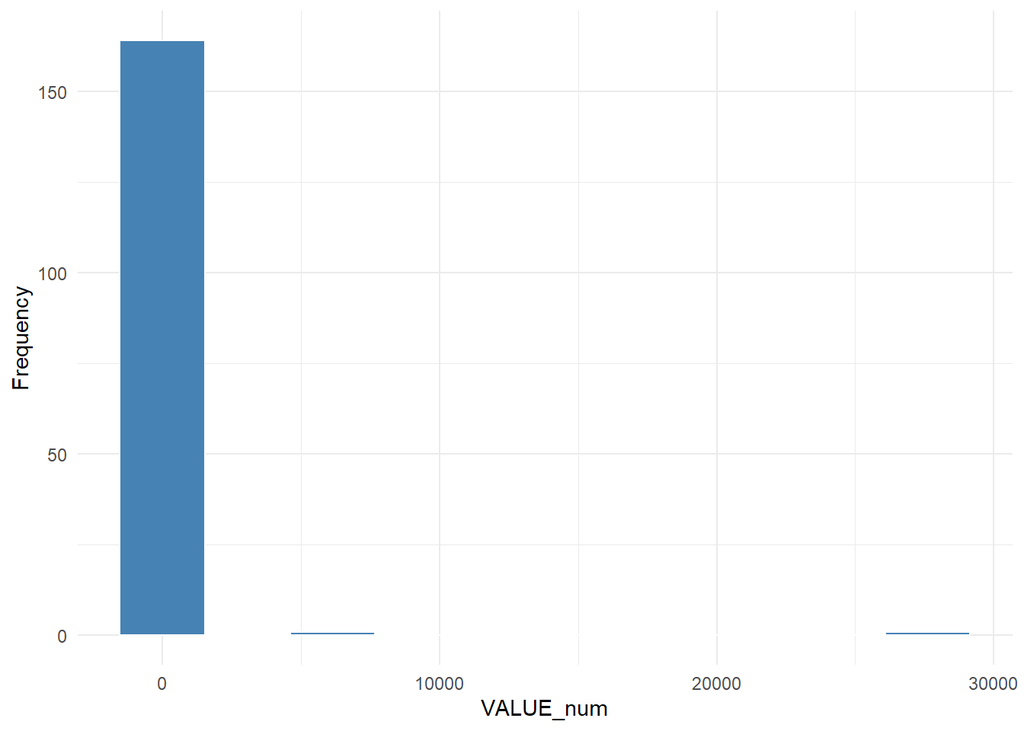

```r
ggplot(df_dta, aes(x = VALUE_num)) +
  geom_histogram(bins = 10, fill = "steelblue", color = "white") +
  labs(
    x = "VALUE_num",
    y = "Frequency"
  ) +
  theme_minimal()
```

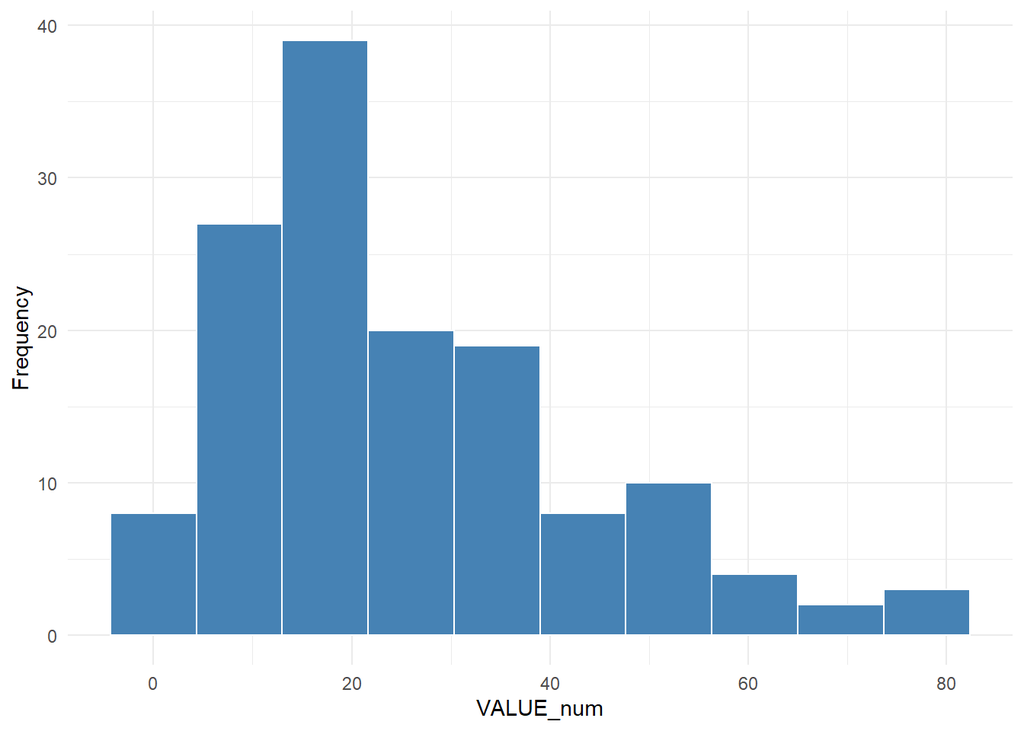

```r
df_filtered <- df_dta %>%
  filter(grepl("%", UNIT))

ggplot(df_filtered, aes(x = VALUE_num)) +
  geom_histogram(bins = 10, fill = "steelblue", color = "white") +
  labs(
    x = "VALUE_num",
    y = "Frequency"
  ) +
  theme_minimal()
```

### 5.2.4 MEASURE

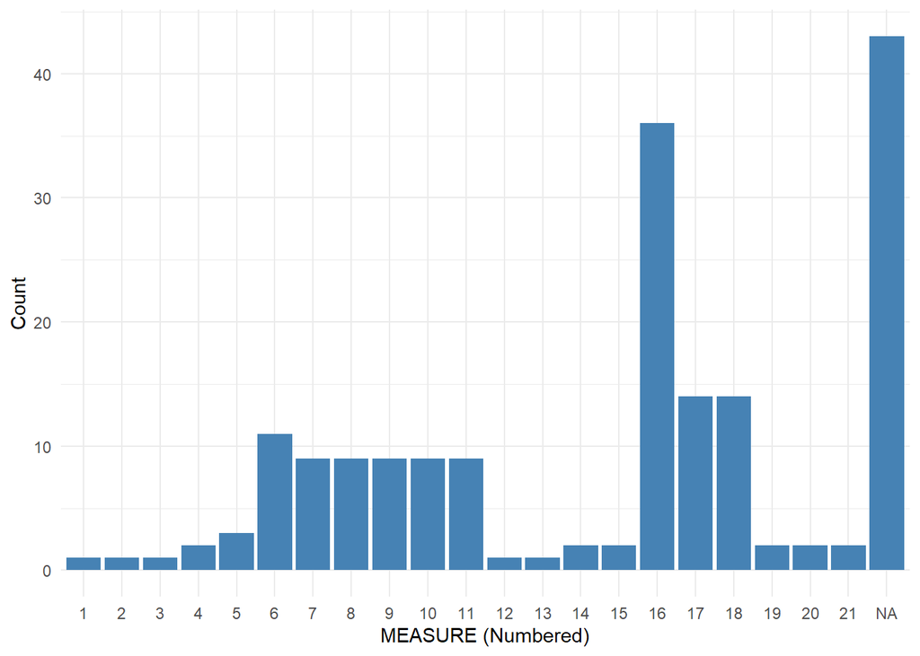

```r
df_dta_tmp <- df_dta %>%
  mutate(tmp_ID = as.numeric(factor(MEASURE)))

ggplot(df_dta_tmp, aes(x = factor(tmp_ID))) +
  geom_bar(fill = "steelblue") +
  labs(
    x = "MEASURE (Numbered)",
    y = "Count"
  ) +
  theme_minimal()
```

```r
lookup_table <- df_dta_tmp %>%
  select(tmp_ID, MEASURE) %>%
  distinct() %>%
  arrange(tmp_ID)

kable(lookup_table)
```

| tmp_ID | MEASURE |
| --- | --- |
| 1 | Costs for healthcare payer |
| 2 | Participants who received a diagnosis >2 months after 1st consultation |
| 3 | Participants who received diagnosis >1 year after 1st consultation |
| 4 | Participants who reduced their working hours or did not return to work due to their health status |
| 5 | Participants who reported having a very or rather burdensome treatment |
| 6 | Participants who reported having the associated comorbidity |
| 7 | Participants who reported moderate, severe or extreme problems with anxiety/depression |
| 8 | Participants who reported moderate, severe or extreme problems with mobility |
| 9 | Participants who reported moderate, severe or extreme problems with pain/discomfort |
| 10 | Participants who reported moderate, severe or extreme problems with self-care |
| 11 | Participants who reported moderate, severe or extreme problems with usual activities |
| 12 | Participants who reported needing social support in at least one area but did not receive it |
| 13 | Participants who reported needing social support in at least one area but did not receive it, excluding ‘To speak with healthcare professionals (including a psychologist)’ |
| 14 | Participants who reported receiving insufficient, no information or too much information |
| 15 | Participants who reported that the information received was not very clear or not clear at all |
| 16 | Participants who reported the physical symptom as very or rather burdensome (>10%) |
| 17 | Participants who reported the psychological symptom as very or rather burdensome (>10%) |
| 18 | Participants who reported the side-effect as very or rather burdensome (>10%) |
| 19 | Participants who reported wanting to have been more involved in treatment choice |
| 20 | Participants who within the last 12 months reported not receiving care when needed |
| 21 | Working individuals before disease who stopped working for at least 1 month and returned to work with reduced schedule or did not return to work |
| NA | NA |

### 5.2.5 UNIT

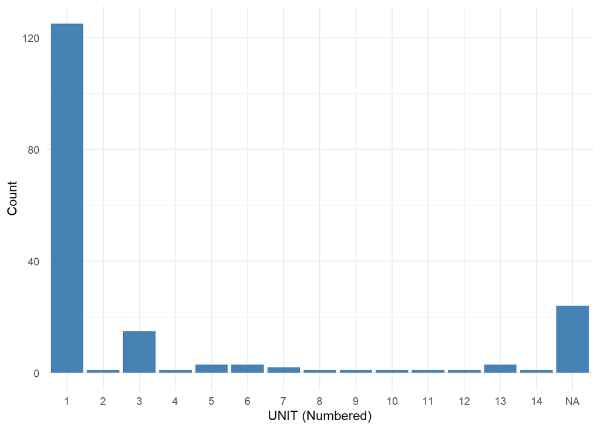

```r
df_dta_tmp <- df_dta %>%
  mutate(tmp_ID = as.numeric(factor(UNIT)))

ggplot(df_dta_tmp, aes(x = factor(tmp_ID))) +
  geom_bar(fill = "steelblue") +
  labs(
    x = "UNIT (Numbered)",
    y = "Count"
  ) +
  theme_minimal()
```

```r
lookup_table <- df_dta_tmp %>%
  select(tmp_ID, UNIT) %>%
  distinct() %>%
  arrange(tmp_ID)

kable(lookup_table)
```

| tmp_ID | UNIT |
| --- | --- |
| 1 | % |
| 2 | % of the population |
| 3 | % points |
| 4 | € (billion) |
| 5 | € (million) |
| 6 | € per patient per month |
| 7 | € per year |
| 8 | Age-standardised incidence per 100 000 |
| 9 | Incidence rate per 100 000 |
| 10 | per 100 000 |
| 11 | Prevalence |
| 12 | Prevalence rate per 100 000 |
| 13 | YLD/case |
| 14 | YLL/death |
| NA | NA |

### 5.2.6 KEY_POINT & QUOTES

```r
summary_table <- data.frame(
  Variable = c("KEY_POINT", "QUOTES"),
  Row_Count = c(nrow(df_dta_kp), nrow(df_dta_qt)),
  Distinct_Count = c(n_distinct(df_dta_kp$KEY_POINT), n_distinct(df_dta_qt$QUOTES))
)

# Display with kable
kable(summary_table, caption = "Summary of KEY_POINT and QUOTES Variables")
```

Summary of KEY_POINT and QUOTES Variables

| Variable | Row_Count | Distinct_Count |
| --- | --- | --- |
| KEY_POINT | 197 | 129 |
| QUOTES | 196 | 140 |

## 5.3 Multivariate

### 5.3.1 DISEASE x DIMENSION

```r
crossTable <- table(df_dta$fDISEASE, df_dta$fDIMENSION)
crossTable_df <- as.data.frame.matrix(crossTable)
kable(crossTable_df, caption = "Cross Table of fDISEASE and fDIMENSION")
```

Cross Table of fDISEASE and fDIMENSION

|  | Future | Patients | Society |
| --- | --- | --- | --- |
| Crohns Disease | 0 | 76 | 4 |
| Long COVID | 0 | 43 | 1 |
| Malignant melanoma | 2 | 50 | 7 |

### 5.3.2 DISEASE x DOMAIN

```r
crossTable <- table(df_dta$fDISEASE, df_dta$fDOMAIN)
crossTable_df <- as.data.frame.matrix(crossTable)
kable(crossTable_df, caption = "Cross Table of fDISEASE and fDOMAIN")
```

Cross Table of fDISEASE and fDOMAIN

|  | Health | Healthcare | Social |
| --- | --- | --- | --- |
| Crohns Disease | 57 | 16 | 7 |
| Long COVID | 37 | 4 | 3 |
| Malignant melanoma | 32 | 20 | 7 |

### 5.3.3 DISEASE x CRITERION

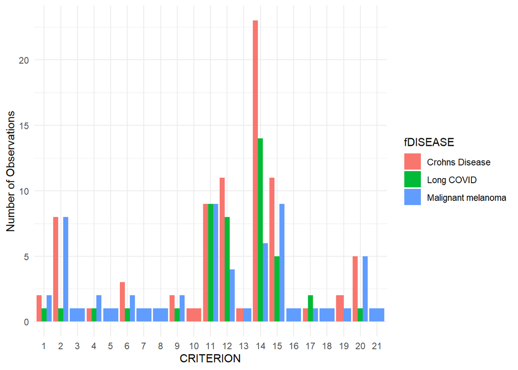

```r
df_summary <- df_dta %>%
  group_by(fCRITERION, fDISEASE) %>%
  summarise(Count = n(), .groups = "drop") %>%
  mutate(CRIT_ID = as.numeric(factor(fCRITERION)))

# Plot with criterion number on x-axis
ggplot(df_summary, aes(x = as.factor(CRIT_ID), y = Count, fill = fDISEASE)) +
  geom_bar(stat = "identity", position = "dodge") +
  labs(
    x = "CRITERION",
    y = "Number of Observations"
  ) +
  theme_minimal()
```

```r
criterion_mapping <- df_summary %>%
  select(CRIT_ID, fCRITERION) %>%
  distinct() %>%
  arrange(CRIT_ID)

kable(criterion_mapping, caption = "Mapping of CRIT_ID to fCRITERION")
```

Mapping of CRIT_ID to fCRITERION

| CRIT_ID | fCRITERION |
| --- | --- |
| 1 | Accessibility |
| 2 | Burden of treatment |
| 3 | Burden on informal caregivers |
| 4 | Effectiveness of treatment |
| 5 | Environmental impact of standard of care |
| 6 | Financial consequences |
| 7 | Forecasted healthcare costs |
| 8 | Forecasted productivity losses |
| 9 | Frequency |
| 10 | Impact of social life |
| 11 | Impact on autonomy |
| 12 | Impact on general health-related quality of life |
| 13 | Impact on life expectancy |
| 14 | Impact on physical health |
| 15 | Impact on psychological health |
| 16 | Impact on social life |
| 17 | Impact on work |
| 18 | Preventability |
| 19 | Productivity losses |
| 20 | Quality of care |
| 21 | Value for money of standard of care |

### 5.3.4 MEASURE x UNIT x VALUE

```r
crosstable <- df_dta %>%
  mutate(
    VALUE_present   = !is.na(VALUE),
    MEASURE_present = !is.na(MEASURE),
    UNIT_present    = !is.na(UNIT)
  ) %>%
  count(VALUE_present, MEASURE_present, UNIT_present) %>%
  arrange(desc(n))

print(crosstable)
```

```
## # A tibble: 5 × 4
##   VALUE_present MEASURE_present UNIT_present     n
##   <lgl>         <lgl>           <lgl>        <int>
## 1 TRUE          TRUE            TRUE           140
## 2 TRUE          FALSE           FALSE           17
## 3 TRUE          FALSE           TRUE            17
## 4 FALSE         FALSE           FALSE            7
## 5 FALSE         FALSE           TRUE             2
```

### 5.3.5 VALUE x KEYPOINTS x QUOTES

```r
crosstable <- df_dta %>%
  mutate(
    MEASURE_present = !is.na(VALUE),
    VALUE_present   = !is.na(KEY_POINT),
    UNIT_present    = !is.na(QUOTES)
  ) %>%
  count(MEASURE_present, VALUE_present, UNIT_present) %>%
  arrange(desc(n))

print(crosstable)
```

```
## # A tibble: 6 × 4
##   MEASURE_present VALUE_present UNIT_present     n
##   <lgl>           <lgl>         <lgl>        <int>
## 1 TRUE            FALSE         FALSE          109
## 2 TRUE            TRUE          TRUE            36
## 3 TRUE            FALSE         TRUE            18
## 4 TRUE            TRUE          FALSE           11
## 5 FALSE           TRUE          TRUE             7
## 6 FALSE           TRUE          FALSE            2
```

# 6 Export cleaned data

```r
write_feather(df_dta, "../Data/Cleaned/df_dta_cleaned.feather")
write.xlsx(df_dta, "../Data/Cleaned/df_dta_cleaned.xlsx")

write_feather(df_dta_kp, "../Data/Cleaned/df_dta_kp_cleaned.feather")
write.xlsx(df_dta_kp, "../Data/Cleaned/df_dta_kp_cleaned.xlsx")

write_feather(df_dta_qt, "../Data/Cleaned/df_dta_qt_cleaned.feather")
write.xlsx(df_dta_qt, "../Data/Cleaned/df_dta_qt_cleaned.xlsx")
```